# Methods for Data Science: Course Work 1

```python
import numpy as np
import pandas as pd
import seaborn as sns
import matplotlib.pyplot as plt
from google.colab import files
from collections import defaultdict
```

```python
alldata = files.upload()
```

Upload widget is only available when the cell has been executed in the current browser session. Please rerun this cell to enable.

```
Saving airfoil_noise_samples.csv to airfoil_noise_samples.csv
Saving airfoil_noise_test.csv to airfoil_noise_test.csv
Saving diabetes_samples.csv to diabetes_samples.csv
Saving diabetes_test.csv to diabetes_test.csv
```

## Task 1: Regression (50 marks)

### Data loading, cleaning, and visualisation

By inspecting the first ten rows of our *airfoil_sample* dataframe, we can tell there are 7 columns in total. Our target variable, sound pressure, sits in the last column; the first 6 columns will be used as predictors of our target variable.

Our printed messages show us 1: all the columns are numerical; 2: every data is valid, neither Inf nor NaN is contained in the dataframe.

Outliers are not examined and dropped here because the same conditions can also happen in our test set (real world), we want our model to fit for these scenarios.

```python
airfoil_sample = pd.read_csv('airfoil_noise_samples.csv')
print("---First 10 rows of airfoil samples-- ")
print(airfoil_sample.head(10))

print("---------------------------------")
print("---Check for numerical columns---")
print([(column, airfoil_sample[column].dtype.kind in 'iufcb') for column in airfoil_sample.columns])

print("---------------------------------")
print("---Check for Inf/NaN---")
airfoil_sample.isin([np.inf, -np.inf]).any() & airfoil_sample.isnull().any()
```

```
---First 10 rows of airfoil samples--
     Frequency      Angle  Displacement  Chord length   Velocity  Thickness  \
0  2175.611424  15.138865     21.075119      0.088194  66.764401   0.044771
1  2962.923620  13.400893     13.200889      0.048462  78.221903   0.011041
2  4430.810843   2.164599     13.959536      0.226743  57.053201   0.011499
3  4939.695645  13.857682     18.203793      0.021705  23.896377   0.021475
4  2193.979785   9.298757     11.007713      0.052737  38.917034   0.001741
5  1555.843040   8.048993      9.227235      0.088870  32.835170   0.006553
6   850.307974   2.588876     15.608633      0.290574  26.223894   0.003139
7  2892.383673   0.052070      3.345630      0.016743  69.994584   0.002674
8  4791.451768  12.136246     17.311292      0.067119  36.479706   0.028416
9  1796.144952  14.958928     20.145914      0.119946  67.887560   0.046078

   Sound Pressure
0      122.365215
1      129.296236
2      121.827380
3      114.998132
4      125.639641
5      129.918050
6      122.351477
7      134.570591
8      117.735889
9      124.442022
---------------------------------
---Check for numerical columns---
[('Frequency', True), ('Angle', True), ('Displacement', True), ('Chord length', True), ('Velocity', True), ('Thickness', True), ('Sound Pressure', True)]
---------------------------------
---Check for Inf/NaN---
```

```
Frequency         False
Angle             False
Displacement      False
Chord length      False
Velocity          False
Thickness         False
Sound Pressure    False
dtype: bool
```

Same loading and cleaning procedure is applied to our test dataframe *airfoil_test*. By examing the output, we could tell our test dataframe is valid and good to go as well.

```python
airfoil_test = pd.read_csv('airfoil_noise_test.csv')
print("---First 10 rows of airfoil samples-- ")
print(airfoil_test.head(10))

print("---------------------------------")
print("---Check for numerical columns---")
print([(column, airfoil_test[column].dtype.kind in 'iufcb') for column in airfoil_test.columns])

print("---------------------------------")
print("---Check for Inf/NaN---")
airfoil_test.isin([np.inf, -np.inf]).any() & airfoil_test.isnull().any()
```

```
---First 10 rows of airfoil samples--
     Frequency      Angle  Displacement  Chord length   Velocity  Thickness  \
0  1143.654418  12.783087     15.277127      0.110389  46.089548   0.024076
1   619.208992   4.460285     16.198696      0.284357  36.728360   0.004000
2   646.114737   2.521952      7.533605      0.072292  59.498237   0.003590
3  1246.777461   8.438129     12.396435      0.034411  47.557277   0.002407
4   286.200927  12.238350     20.877161      0.082437  72.786590   0.036883
5   497.618583   7.435535     15.242898      0.132067  62.347478   0.001657
6  5275.370821   3.033078      9.747409      0.134838  57.112204   0.005682
7  2729.967513  11.529228     19.058322      0.141772  34.877830   0.058157
8  2163.049145   9.371793      7.413034      0.047968  58.659275   0.008009
9  1306.344254   9.954367     14.845855      0.116116  67.140211   0.028452

   Sound Pressure
0      125.332111
1      122.801183
2      129.361188
3      125.656263
4      124.241736
5      126.903749
6      122.096099
7      119.055734
8      128.155787
9      125.751489
---------------------------------
---Check for numerical columns---
[('Frequency', True), ('Angle', True), ('Displacement', True), ('Chord length', True), ('Velocity', True), ('Thickness', True), ('Sound Pressure', True)]
---------------------------------
---Check for Inf/NaN---
```

```
Frequency         False
Angle             False
Displacement      False
Chord length      False
Velocity          False
Thickness         False
Sound Pressure    False
dtype: bool
```

Before proceeding to regression fitting, we inspect the relationship between each predictor and our target variable.

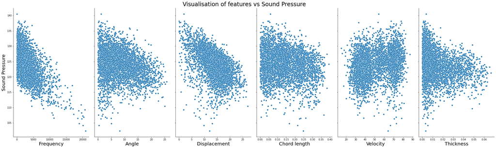

```python
# Plot the training set versus target variable
g = sns.pairplot(airfoil_sample, x_vars=airfoil_sample.columns[:6], y_vars=airfoil_sample.columns[6])
g.fig.suptitle("Visualisation of features vs Sound Pressure", fontsize=24, y=1)
g.fig.set_size_inches(30, 10)
# Increase the font size of the x- and y-labels
for ax in g.axes.flatten():
    ax.set_xlabel(ax.get_xlabel(), fontsize=20)
    ax.set_ylabel(ax.get_ylabel(), fontsize=20)
```

We can say there will be apparent negative correlation between frequency vs sound pressure and displacement vs sound pressure respectively. Chord length , velocity may have less correlation to our target.

#### 1.1 Linear regression (8 marks)

1.1.1

We first recall a rescaling feature -- standarisation, which is defined as follows: for feature $x$,

$$ x_{\text{std}} = \frac{x - \text{mean}(x)}{\text{standard deviation}(x)} $$

Here I just use the great standardisation function from the provided notebook.

```python
def standardise(X_train):
    """
    Standardize the input data by subtracting the mean and dividing by the
    standard deviation.

    :param X_train: A numpy array of shape (N, d) representing the training data.
    :param X_test: A numpy array of shape (N, d) representing the test data.

    :return: A numpy array of the same shape as X, with each feature normalized
             to have zero mean and unit variance.
    """
    # Calculate the mean and standard deviation of each feature
    mu = np.mean(X_train, 0)
    sigma = np.std(X_train, 0)

    # Standardize the training dataset
    X_std = (X_train - mu) / sigma

    return X_std
```

To prepare for our analysis, we need to extract the feature set and target set from the training dataframe *airfoil_sample*. We will only standardise the feature set, while keeping the target set in its original form. This is because we want to preserve the scale of the target variable for the interpretability of the model, as changing its scale could shift the intercept.

Instead of working with the equation $\boldsymbol y = \boldsymbol X \beta + \beta_0$, we will use an augmented matrix that includes a column of ones at the beginning of $\boldsymbol X$. The parameter vector $\beta$ will be updated to include β0 at the top as follows:

$$ X' = (1 | X) \space \text{and} \space \beta' = (\beta_0 | \beta)^T $$

With this setup, our model can be expressed as $\boldsymbol Y = X'\beta'$

```python
#Define the training sets for sound pressure
Xsp_train = airfoil_sample[airfoil_sample.columns[:-1]]
ysp_train = airfoil_sample[airfoil_sample.columns[-1]]

#Standardisation
Xsp_train = standardise(Xsp_train.to_numpy())
#Change y to numpy
ysp_train = ysp_train.to_numpy()

#Augumented the training input
N, D = Xsp_train.shape
Xsp_train_aug = np.hstack([np.ones((N,1)), Xsp_train])

#Save the column names as an array
airfoil_columns = airfoil_sample.columns.to_numpy()
```

Our goal now is to minimise the loss function defined as $$L(\beta) = \frac{1}{2N} \|\boldsymbol y - \boldsymbol X \beta - \beta_0\|^2 = \frac{1}{2N}\|y-\boldsymbol X' \beta'\|^2$$ where I use the augument matrix form we just defined.

It is worth noting that this loss function differs from the one (2.5) defined in the lecture notes only by a constant factor of 1/2, which does not affect the location of the minimum. The scale of the loss function will be different, but the relative size of the loss between different sets of parameters will remain the same. Therefore, the parameter $\boldsymbol \beta^*$ that minimizes the loss function will be the same as the one we deduced in the lecture notes.

Therefore, To obtain the least squares solution, same formula for least square solution is used: $\boldsymbol \beta^* = (\boldsymbol X'^T \boldsymbol X')^{-1} \boldsymbol X'^T y = \boldsymbol X'^+ \boldsymbol y$ where $\boldsymbol X'^+$ is the Moore-Penrose pseudo-inverse of $\boldsymbol X'$

```python
def max_lik_estimate(X, y):
    """
    Find the least square estimator of loss function L(beta) through maximum
    likelihood estimation.

    :param X: (N, M) numpy array, predictors (augmented)
    :param y: (N, 1) numpy array, target variable

    :return beta: (M, 1) numpy array, least square estimators including
                   intercept term
    """
    #Calculate the least squares estimator using the Moore-Penrose pseudoinverse
    beta = np.linalg.pinv(X) @ y

    return beta
```

Then we train our model based on our training dataframe, and use it to predict on the target set.

```python
#Fit our model
beta111 = max_lik_estimate(Xsp_train_aug, ysp_train)

#Present the parameters
predictors = np.hstack((np.array(['Intercept']), airfoil_columns[:-1]))
predictors_coefs = dict(zip(predictors, beta111))
print("---Inferred values of model parameters---")
for column_name, coef in predictors_coefs.items():
    print("Coefficient of {}: {}".format(column_name, coef))
```

```
---Inferred values of model parameters---
Coefficient of Intercept: 123.97028331480638
Coefficient of Frequency: -3.57549692953675
Coefficient of Angle: 0.8344780036769042
Coefficient of Displacement: -3.9286472086061517
Coefficient of Chord length: -0.07833419790662706
Coefficient of Velocity: 1.724956675510456
Coefficient of Thickness: -0.013563397924562848
```

The intercept represents the estimated average sound pressure will be around 123.97 units when all the independent variables are zero.

As we can see, coefficients of frequency and displacement has largest values in magnitude, suggesting they have more influence than other predictors to sound pressure. This is consistent to our pairplot presented before. While changes in chord length and thickness have minor influence to sound pressure.

Next I will use my inferred parameters to predict on our training target set, to see how my model fit our training set.

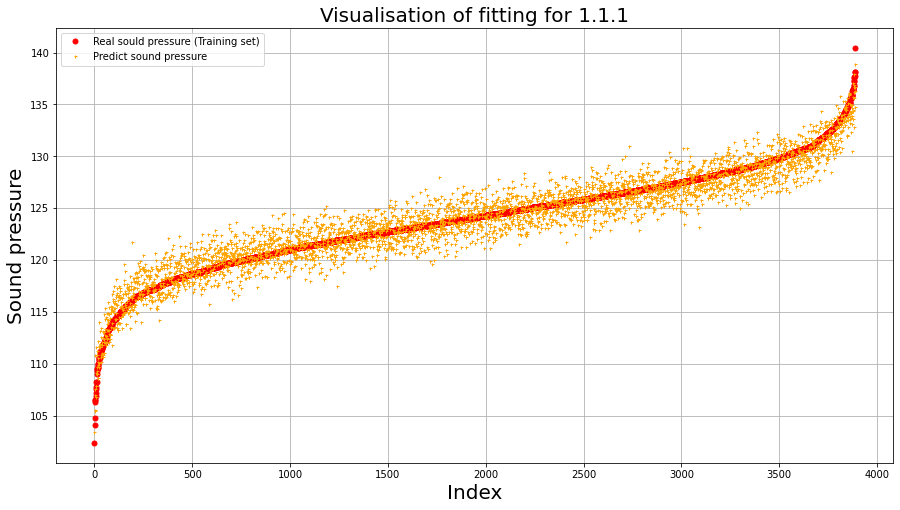

```python
#Predict sound pressure
ysp_predict111 = Xsp_train_aug @ beta111

#Sort the predict value accoring to sorted true value
ysp_predict_sort = ysp_predict111[np.argsort(ysp_train)]

#Visualisation of the fit
plt.figure(figsize=(15,8))
plt.xlabel(r"Index", size=20)
plt.ylabel(r"Sound pressure", size=20)
plt.title(r"Visualisation of fitting for 1.1.1", size=20)
plt.plot(np.sort(ysp_train), ".", color = "red", markersize="10", label="Real sould pressure (Training set)")
plt.plot(ysp_predict_sort, "+", color = "orange", markersize="3", label="Predict sound pressure")
plt.legend()
plt.grid()
plt.show()
```

The visualisation shows our predicted sound pressure are closely surrounded around the true sound pressure, which is a good sign.

Now let us examine our fit numerically.

Firstly recall the mean square error (MSE), which is defined as follows. It measures the average difference between the predicted and actual values of the response variable in a data set. A lower MSE indicates a better fit of the model to our dataset. $$ MSE(y, \hat{y}) = \frac{1}{N}\sum_{i=1}^n (y_i - \hat{y}_i)^2 $$

Secondly, $R^2$ score, which measures the proportion of the total variation in the response variable that is explained by the model, which is a measure of how well the model fits the data.A higher R^2 score indicates a better fit of the model to the training data. It is defined as $$ R^2(y, \hat{y}) = 1 - \frac{\sum_{i=1}^n (y_i - \hat{y}_i)^2}{\sum_{i=1}^n (y_i - \bar{y})^2} $$

Implementations are as follow.

```python
def MSE(y_test, y_pred):
    """
    Calculate the mean squared error (MSE) between y_test and y_pred.

    :param y_test: (N, 1) numpy array, test target variable
    :param y_pred: (N, 1) numpy array, predicted target variable

    :return mse: float, mean square error of the fitting
    """

    mse = np.mean((y_test - y_pred)**2)

    return mse

def r2_score(y_test, y_pred):
    """
    Compute the R^2 score of our prediction.

    :param y_test: (N, 1) numpy array, test target variable
    :param y_pred: (N, 1) numpy array, predicted target variable

    :return r2_score: float, r^2 score of our fitting
    """
    #Calculate the sum of squared residuals (SSR)
    ssr = np.sum((y_test - y_pred)**2)
    #Calculate the total sum of squares (SST)
    sst = np.sum((y_test - np.mean(y_test))**2)

    return 1 - ssr / sst
```

```python
print("---Evaluation for 1.1.1---")
print("In-sample MSE: ", MSE(ysp_train, ysp_predict111))
print("In-sample r2 score: ", r2_score(ysp_train, ysp_predict111))
```

```
---Evaluation for 1.1.1---
In-sample MSE:  1.8755566396402021
In-sample r2 score:  0.9177343977263077
```

Mean squared error (MSE) of 1.8755 suggests that the regression model has a relatively low error, predicts points are fairly around the true values, it is a good fit for the data.

A $R^2$ score of 0.9177 means that 91.77% of the variation in the response variable is explained by the model, while the remaining 8.23% is due to random error or other factors not captured by the model. This is a quite good sign that our model is fitting well on our training set.

1.1.2

As I have checked that the test date set *airfoil_test* is valid at the start, I now go straightly into extrating feature set and target set, following the same procedure in section 1.1.1.

```python
#Define the test test for sound pressure
Xsp_test = airfoil_test[airfoil_test.columns[:-1]]
ysp_test = airfoil_test[airfoil_test.columns[-1]]

#Standardise our test set
Xsp_test = standardise(Xsp_test.to_numpy())
#Change y to numpy
ysp_test = ysp_test.to_numpy()

#Form augumented matrix
N, D = Xsp_test.shape
Xsp_test_aug = np.hstack([np.ones((N,1)), Xsp_test])
```

I apply our inferred parameter *beta111* to predict the sound pressure in *airfoil_test*, and then compare it to the true sound pressure in test set.

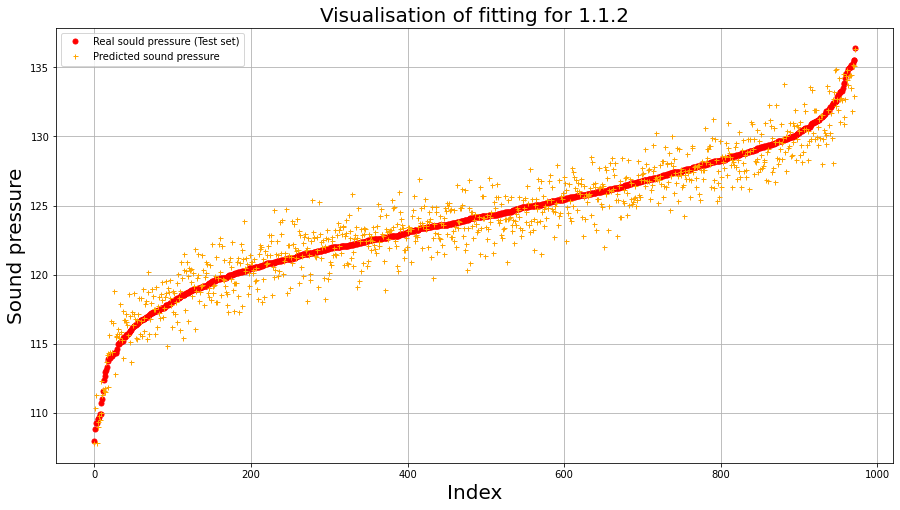

```python
#beta112 = max_lik_estimate(Xsp_test_aug, ysp_test)
ysp_predict112 = Xsp_test_aug @ beta111

#Sort predict values according to sorted true value
ysp_predict_sort = ysp_predict112[np.argsort(ysp_test)]

#Visualisation of the fit
plt.figure(figsize=(15,8))
plt.xlabel(r"Index", size=20)
plt.ylabel(r"Sound pressure", size=20)
plt.title(r"Visualisation of fitting for 1.1.2", size=20)
plt.plot(np.sort(ysp_test), ".", color = "red", markersize="10", label="Real sould pressure (Test set)")
plt.plot(ysp_predict_sort, "+", color = "orange", markersize="5", label="Predicted sound pressure")
plt.legend()
plt.grid()
plt.show()
```

Follow the same methodology as above, I create such visualition of fitting. Compare to the our last plot, the yellow dots (predicted value) are kindly more sparse from the red dots (true value), It suggests the out-sample fitting is less accurate than in-sample fitting.

Now let us see what our numerical evaluation is showing.

```python
print("---Evaluation for 1.1.2---")
print("Out-sample MSE: ", MSE(ysp_test, ysp_predict112))
print("Out-sample r2 score: ", r2_score(ysp_test, ysp_predict112))
```

```
---Evaluation for 1.1.2---
Out-sample MSE:  2.004375595582506
Out-sample r2 score:  0.9073938520660663
```

MSE being 2.00 still suggests that the regression model has a relatively low error and is a good fit for the test data; $R^2$ score of 0.907 means that 90.7% of the variation in the response variable is explained by the model. This is also a quite good sign that our model is fitting well on our test set.

However, it is more interesting to compare the fit of our model on traing set and test set alongside.

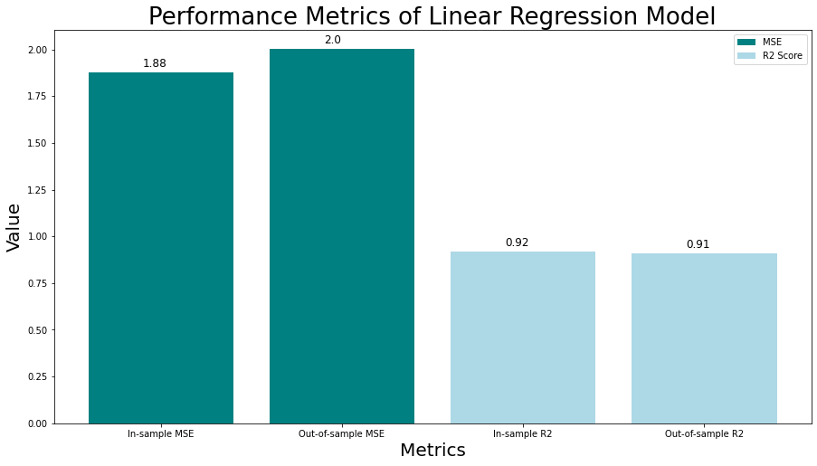

```python
#Visaulisation
metrics = ['In-sample MSE', 'Out-of-sample MSE', 'In-sample R2', 'Out-of-sample R2']
values = [MSE(ysp_train, ysp_predict111), MSE(ysp_test, ysp_predict112), r2_score(ysp_train, ysp_predict111), r2_score(ysp_test, ysp_predict112)]

# Create the figure and axes
fig, ax = plt.subplots(figsize=(15, 8))

# Create the bar chart for MSE
ax.bar(metrics[:2], values[:2], color='teal', label='MSE')

# Create the bar chart for R2 score
ax.bar(metrics[2:], values[2:], color='lightblue', label='R2 Score')

# Set the title and axis labels
ax.set_title('Performance Metrics of Linear Regression Model', fontsize=26)
ax.set_xlabel('Metrics', fontsize=20)
ax.set_ylabel('Value', fontsize=20)

# Add values on the bars
for i, v in enumerate(values):
    ax.text(i-0.1, v+0.03, str(round(v, 2)), fontsize=12)

# Show the plot
plt.legend()
plt.show()
```

As I discussed before, a lower MSE and higher R2 score indicate a better fit of the model to the data. This plot shows that our model is performing less well on *airfoil_test* compared to *airfoil_sample*. As the out-of-sample MSE is higher and out-of-samle $R^2$ is lower.

Although our out-of-sample still has quite good fitting, and the difference with in-sample result is minor, it could suggests that our model is *overfitting* the training data and not generalizing well to new data. This could happen if some parameters are redundant / correlated to one another. This issue will be addressed in following section.

#### 1.2 Lasso regression (12 marks)

1.2.1

In this section, I implement the lasso regression with loss function defined as $L(\beta) = \frac{1}{2N} \|y-\boldsymbol X \beta - \beta_0 \|_2^2 + \lambda \|\beta\|_1$ and find the optimal penalty hyper-parameter $\lambda$ for our data set *airfoil_sample*.

Let me write the first 2-norm in augmented matrix form as I did in section 1.1.1. notice I leave the 1-norm unchanged as regularisation is not applied to the intercept $\beta_0$: $$ L_{\text{Lasso}}(\beta) = \frac{1}{2N} \|y-\boldsymbol X' \beta' \|_2^2 + \lambda \|\beta\|_1 $$

As we are using the Gradient Descent appraoch to minimise $L$, we firstly find its derivative. Consider the 1-norm first, by definition, for $x \in \mathbb{R}^n$, $$\|x\|_1 = \sum_{k=1}^n |x_k|$$ However, this absolute function is apparently not differentiable at $x_k=0$, we then perform a hack by smoothing out our 1-norm, making it pairwise differentiable as:

$$ \frac{d}{d x_k}\left|x_k\right|=\left\{\begin{array}{cc} 0 & \text { if } x_k=0 \\ \frac{x_k}{\left|x_k\right|} & \text { if } x_k \neq 0 \end{array}\right. $$

Notice that

$$ \frac{x_k}{\left|x_k\right|}=\left\{\begin{aligned} 1 \quad & \text { if } x_k>0 \\ -1 \quad & \text { if } x_k<0 \end{aligned}\right. $$

Regarding the derivative of $\|y-X'\beta'\|_2^2$, consider the definition of $\|x\|_2^2$ for $x \in \mathbb{R}^n$:

$$ \|x\|_2^2=\left(\left(\sum_{k=1}^n x_k^2\right)^{1 / 2}\right)^2=\sum_{k=1}^n x_k^2 $$$$ \frac{\partial}{\partial x_j} \|x\|_2^2=\frac{\partial}{\partial x_j} \sum_{k=1}^n x_k^2=\sum_{k=1}^n \frac{\partial}{\partial x_j} x_k^2 =2 x_j \implies \nabla \|x\|_2^2=2 x $$

From the lecture notes, we know $\nabla_\beta(X^T \beta) = X$, then $\nabla_\beta(X' \beta) = (X')^T$.

Finally by the chain rule, we have the derivative of loss function as $$ \frac{\partial L_{\text{Lasso}}}{\partial \beta} = \frac{1}{N}(-\boldsymbol X')^T(y-\boldsymbol X' \beta) + \lambda sign(\beta) $$

The gradient descent appraoch is implemented as follow, then we use our estimated parameters to fit data sets, MSE is used to check our fittings.

The stopping critiera is chosen as the percentage change of loss after each iteration.

```python
def lasso_estimate(X, y, lambda_, constmul = 10, max_iter=100000, tol=1e-7):
    """
    Perform Lasso Regression using Gradient Descent.

    :param X: (N, M) numpy array, predictors set (augmented)
    :param y: (N, 1) numpy array, target variable
    :param lambda_: float, penalty of lasso, hyper-parameter
    :param constmul: float, constant multiplier for gradient descent
    :param max_iter: integer, maximum number of iteration allowed
    :param tol: float, tolerance for convergence

    :return beta: (M, 1) numpy array least square estimators including intercept
    """
    N, M = X.shape

    # initialize beta with all zeros
    beta = np.zeros(M)
    # Initialize old_loss with a large value
    old_loss = float('inf')

    #Loop through gradient descent with a maximum number of iterations
    #or until the loss decreases by the tolerance
    for niter in range(1, max_iter+1):

        #set the learning rate to decrease with iteration number
        learning_rate = constmul / niter
        # predict targets values using the current coefficients and intercept
        y_pred = X @ beta
        # calculate the loss value
        loss = 1/(2*N) * np.linalg.norm(y - y_pred)**2 + lambda_ * np.linalg.norm(beta[1:], ord=1)
        # terminate if percentage change in loss is smaller than epsilon
        if np.abs(loss - old_loss) / old_loss < tol:
            break

        #update old_loss to current loss
        old_loss = loss
        # update the gradient of beta and beta_0
        grad_beta = -1/N * X.T @ (y - y_pred)
        grad_beta[1:] += lambda_ * np.sign(beta[1:])

        # update beta using gradient descent
        beta -= learning_rate * grad_beta

    return beta

def lasso_predict(X_train, y_train, X_test, lambda_, constmul=10):
    """
    Make predictions using Lasso Regression with a given lambda value.

    :param X_train: (N, M) numpy array, predictors in training set
    :param y_train: (N, 1) numpy array, target variable in training set
    :param X_test: (N', M) numpy array, predictors in test set
    :param lambda_: float, penalty of lasso, hyper-parameter
    :param constmul: float, the constant multiple of learning rate, default 10

    :return: y_pred (N', 1) numpy array, predicted target values using Lasso Regression
    """
    #Obtain the coefficients from the Lasso Regression training set
    beta = lasso_estimate(X_train, y_train, lambda_, constmul)
    # Predict the target values of test set
    y_pred = X_test @ beta

    return y_pred

def lasso_score(X_train, y_train, X_test, y_test, lambda_, constmul=10):
    """
    Calculates the mean squared error (MSE) of lasso regression on the test data.

    :param X_train: (N, M) numpy array, training predictors set
    :param y_train: (N, 1) numpy array, training target variable
    :param X_test: (N', M) numpy array, test predictors set
    :param y_test: (N', 1) numpy array, test target variable
    :param lambda_: float, penalty of lasso, hyper-parameter
    :param constmul: float, optional, constant multiplier for gradient descent step size

    :return: float, mean squared error of the predicted values on the test set
    """
    #get predicted values using lasso regression
    y_pred = lasso_predict(X_train, y_train, X_test, lambda_, constmul)

    # calculate mean squared error using predicted values and true values
    return MSE(y_test, y_pred)
```

To assess the performance and generalization ability of out lasso models, cross-validation is used to provide an estimate of the expected error of a model on new data, which is given by the expected value of the loss function under the true data distribution. This is done by repeatedly sampling different equal-sized training and testing sets from the available data and estimate the expected error of the model under different sampling schemes. This is a more robust estimate of the model's true performance on new data.

Then I pass a range of hyper-parameters $\lambda$ to take the cross-validation check, and choose the one giving us the least average MSE scores as our optimal hyper-parameter.

```python
def lasso_cross_validation_score(X_train, y_train, fold, lambda_, constmul=10):
    """
    Perform T-fold cross validation on Lasso regression.

    :param X_train: (M, D) numpy array, training set
    :param y_train: (M, 1) numpy array, target variable for training set
    :param fold: int, number of folds
    :param lambda_: float, hyperparameter of Lasso regression
    :param constmul: float, the constant multiplier used in Lasso estimation

    :return: float, average of MSE of all folds
    """
    #Initialize an empty list to store the scores from each fold
    scores = []

    #Divide the training data into T folds
    folds = np.split(np.arange(len(y_train)), fold)

    # Shuffle the data randomly
    p = np.random.permutation(len(y_train))
    X_train = X_train[p]
    y_train = y_train[p]

    #Loop over each fold
    for i in range(len(folds)):
        #Get the validation index for this fold
        val_indexes = folds[i]
        #Get the training index for this fold
        train_indexes = list(set(range(y_train.shape[0])) - set(val_indexes))

        #Get the training data for this fold
        X_train_i = X_train[train_indexes, :]
        y_train_i = y_train[train_indexes]

        #Get the validation data for this fold
        X_val_i = X_train[val_indexes, :]
        y_val_i = y_train[val_indexes]

        #Calculate the score for this fold using the score function
        score_i = lasso_score(X_train_i, y_train_i, X_val_i, y_val_i, lambda_, constmul)
        #Add the score to the list of scores
        scores.append(score_i)

    # Return the average score
    return np.mean(scores)

def lasso_choose_best_lambda(X_train, y_train, fold, lambda_range, constmul=10, plot=False):
    """
    Given a range of lambda values to test, find the lambda value that results in the lowest mean squared error
    when performing k-fold cross-validation.

    :param X_train: (M, D) array, training set
    :param y_train: (M, 1) array, the classifications of X_train
    :param fold: integer, number of folds for cross-validation
    :param lambda_range: list of values of lambda to test
    :param constmul: integer, constant multiplier for the penalty term in Lasso regression

    :return best_lambda: lambda value that resulted in the lowest mean squared error
    :return best_score: the corresponding mean squared error
    :return all_scores: array containing the mean squared errors for all values of lambda in lambda_range
    """
    #Initialize an empy array to score scores for each lambda
    lambda_scores = np.zeros((len(lambda_range),))

    #Loop over each lambda
    for i, lambda_ in enumerate(lambda_range):
        lambda_scores[i] = lasso_cross_validation_score(X_train, y_train, fold, lambda_, constmul)

    #Find the lambda with lowest MSE scores
    best_index = np.argmin(lambda_scores)

    if plot:
        plt.figure(figsize=(15,8))
        plt.plot(np.arange(len(lambda_range)), lambda_scores, marker="o", linestyle='-')
        plt.scatter(best_index, np.min(lambda_scores), marker="*", c='#d62728')
        plt.xlabel(r"Index of lambda", size=20)
        plt.ylabel(r"Cross validation score", size=20)
        plt.title(r"Grid search of $\lambda$", size=20)
        plt.grid()
        plt.show()

        #Estimate and present parameters usinng optimal settings
        beta_optimal = lasso_estimate(X_train, y_train, lambda_range[best_index], constmul)
        predictors = np.hstack((np.array(['Intercept']), airfoil_columns[:-1]))
        predictors_coefs = dict(zip(predictors, beta_optimal))
        print("---Inferred values under optimal lambda---")
        for column_name, coef in predictors_coefs.items():
            print("Coefficient of {}: {}".format(column_name, coef))

    print("-----------------------------------------------------------")
    print(f"------Optimal combination of parameters of lasso regression from [{lambda_range[0]}, {lambda_range[-1]}]-------")
    print(f"Penalty parameter lambda: {lambda_range[best_index]}")
    print(f"resulting cross validation score is: {np.min(lambda_scores)}")

    return lambda_range[best_index], lambda_scores[best_index], lambda_scores
```

As our learng rate in the question is defined as $\frac{k}{N_{iteration}}$ from some constant multiplier $k$, we study what effect different $k$ has.

Lasso regression works by iteratively updating the estimates of the parameters, with each iteration improving the objective function value. The learning rate controls the step size that is taken in the direction of the gradient at each iteration. If the learning rate is too small, the convergence can be very slowly; if it is too large, the algorithm may overshoot the minimum and even diverge. So in general we want it to begin with a large learning rate, and decreases as the interation goes on, but not descreasing too fast. Thus it is essential that we add a multiplier to it neutralise this. It allows the optimization algorithm to converge faster in the beginning and slower towards the end to avoid overshooting the minimum.

As different constant multiplier gives different value in inferred parameters, I choose to experiment with different values of $k$, take it as our second hyper-parameter, performing a grid search of $k$ and $\lambda$, finding out the most optimal combination of those.

```python
def lasso_grid_search(X_train, y_train, fold, lambda_range, constmul_range):
    """
    Performs a grid search to find the best combination of hyperparameters for lasso regression,
    by testing every combination of constant multipliers and penalty parameters in the provided ranges,
    and outputs the combination that gives the lowest cross-validation score.

    :param X_train: (M, D) array, training set
    :param y_train: (M, 1) array, the classifications of X_train
    :param fold: integer, number of folds to use in cross-validation
    :param lambda_range: list of values of penalty parameter lambda to test
    :param constmul_range: list of constant multipliers to use in learning rate

    :return: optimal constant multiplier, optimal lambda, and the resulting cross-validation score
    """
    #Create arrays to store the best scores and lambdas for each constant multiplier
    score_array, best_lambda_array = np.zeros(len(constmul_range)), np.zeros(len(constmul_range))

    print("Grid search for lasso in progress...")
    plt.figure(figsize=(15,8))

    #For each constant multiplier, find the best lambda and score for the provided range of lambda values
    for i, k in enumerate(constmul_range):
        best_lambda, best_scores, all_scores = lasso_choose_best_lambda(Xsp_train_aug, ysp_train, 5, Lambdas, constmul=k)
        #print(f"Cross validation for const multiplier k = {k} finished.")
        score_array[i] = best_scores
        best_lambda_array[i] = best_lambda
        plt.semilogy(np.arange(len(lambda_range)), all_scores, "+", label=f"const_mul = {k}")

    #Find the index of the best combination of constant multiplier and lambda
    best_index = np.argmin(score_array)

    #Find the optimal constant multiplier and lambda
    optimal_constmul = constmul_range[best_index]
    optimal_lambda = best_lambda_array[best_index]

    print("Grid search all finished.")

    #Plot the scores for each value of lambda for each constant multiplier
    plt.scatter(np.arange(len(lambda_range))[best_index], score_array[best_index], s=30, c='#d62728')
    plt.xlabel(r"Index of lambda", size=20)
    plt.ylabel(r"Cross validation score", size=20)
    plt.title(r"Grid search of constant multiplier and $\lambda$ for 1.2.1")
    plt.grid()
    plt.legend()
    plt.show()

    #Output the optimal combination of hyperparameters and the resulting cross-validation score
    print("-----------------------------------------------------------")
    print("---Optimal combination of parameters of lasso regression---")
    print(f"Constant multiplier of learning rate: {optimal_constmul}")
    print(f"Penalty parameter lambda: {optimal_lambda}")
    print(f"resulting cross validation score is: {np.min(score_array)}")

    #Estimate and present parameters usinng optimal settings
    beta_optimal = lasso_estimate(X_train, y_train, optimal_lambda, optimal_constmul)
    predictors = np.hstack((np.array(['Intercept']), airfoil_columns[:-1]))
    predictors_coefs = dict(zip(predictors, beta_optimal))
    print("---Inferred values under optimal lambda---")
    for column_name, coef in predictors_coefs.items():
        print("Coefficient of {}: {}".format(column_name, coef))

    return optimal_constmul, optimal_lambda, np.min(score_array)
```

We scan through the constant multipliers across integers from $[1,15]$, and we scan 50 floating points from $(0,1)$. Here a logarithmically spaced sequence of $\lambda$ is used because, rather than evenly spaced out $\lambda$, for our data set, two very close $\lambda$ could have similar effect in penalty, thus I want increasing stepsizes of $\lambda$ to see the change of effect more clearly.

```
Grid search for lasso in progress...
Grid search all finished.
```

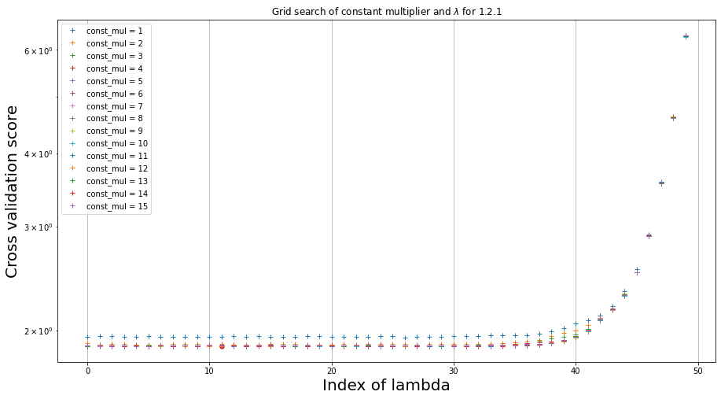

```
-----------------------------------------------------------
---Optimal combination of parameters of lasso regression---
Constant multiplier of learning rate: 12
Penalty parameter lambda: 9.540954763499944e-06
resulting cross validation score is: 1.8786525104841112
---Inferred values under optimal lambda---
Coefficient of Intercept: 123.9702833148064
Coefficient of Frequency: -3.5754241183546718
Coefficient of Angle: 0.838276081989075
Coefficient of Displacement: -3.931506894893078
Coefficient of Chord length: -0.07591103003341501
Coefficient of Velocity: 1.724937204055474
Coefficient of Thickness: -0.013713449412642999
```

```python
Constmuls, Lambdas = np.arange(1,16), np.logspace(-6,0,50)
best_lasso_constmul, best_lasso_lambda, best_lasso_score = lasso_grid_search(Xsp_train_aug, ysp_train, 5, lambda_range=Lambdas, constmul_range=Constmuls)
```

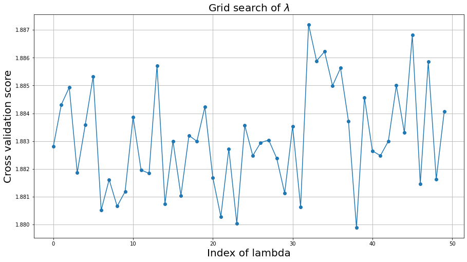

```
---Inferred values under optimal lambda---
Coefficient of Intercept: 123.97028331480637
Coefficient of Frequency: -3.573907672270438
Coefficient of Angle: 0.8311536222135523
Coefficient of Displacement: -3.9266174164497407
Coefficient of Chord length: -0.07810005440494974
Coefficient of Velocity: 1.723651439211371
Coefficient of Thickness: -0.011061331030692916
-----------------------------------------------------------
------Optimal combination of parameters of lasso regression from [1e-06, 0.01]-------
Penalty parameter lambda: 0.0012648552168552957
resulting cross validation score is: 1.8798912427186427
```

```python
constmul, Lambdas = 12, np.logspace(-6,-2,50)
best_lasso_lambda, _, _ = lasso_choose_best_lambda(Xsp_train_aug, ysp_train, 5, Lambdas, constmul=constmul, plot=True)
```

This plot seems to suggest that different lambda is oscillating the average MSE score, but if we look at the y-scale of this point, we can tell the largest difference is even less than 0.01. It means all the lambda in such range performs similarily.

Our optimal $\lambda$ from this search is 0.0012648552168552957, but this is so close to zero, which means that the model is not actually benefiting from the sparsity-inducing effect of the L1 penalty, and all the features are important for predicting the target variable. It is important to note that this does not necessarily mean that regularization is not needed in general, but rather that the specific dataset and model being considered may not benefit from it.

By looking at the inferred parameters, they are almost the same with the parameters in section 1.1.1. This is expected as our $\lambda$ is so small, will not affect our parameters much.

1.2.2

In this section we examine the effect of lasso penalty on our inferred parameter $\beta$. This examination is based on randomly selected sub-set of our training set *airfoil_sample*.

Let us start with the beginning of intercept $\beta_0$.

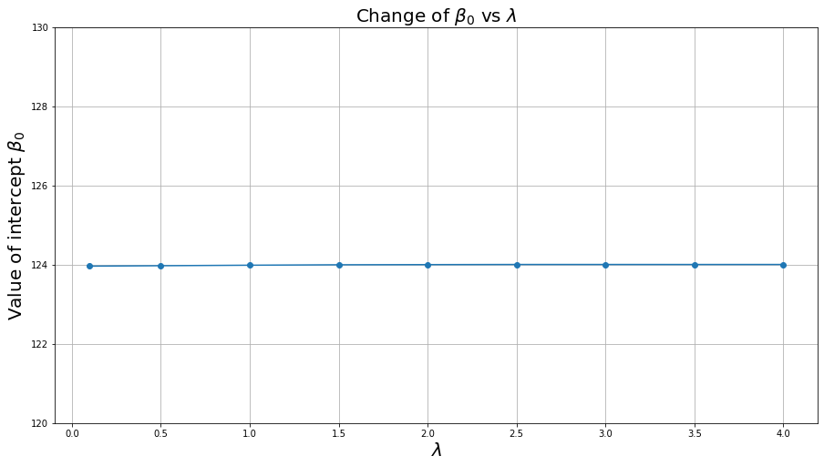

```python
#Randomly choose a subset of training set
N, D = Xsp_train_aug.shape
index_perm = np.random.permutation(np.arange(N))
Xsp_train_perm = Xsp_train_aug[index_perm]
ysp_train_perm = ysp_train[index_perm]
#Split the training and validation set as 4:1
split_rate = 0.8
X_train_122, X_val_122 = np.split(Xsp_train_perm, [int(split_rate*N)])
y_train_122, y_val_122 = np.split(ysp_train_perm, [int(split_rate*N)])

#Range of lambda for testing
lambdas = [0.1, 0.5, 1.0, 1.5, 2.0, 2.5, 3, 3.5, 4.0]

#Loop over each lambda and record beta
beta_list = np.zeros((X_train_122.shape[1], len(lambdas)))
for i, lambda_ in enumerate(lambdas):
    beta_list[:,i] = lasso_estimate(X_train_122, y_train_122, lambda_, constmul=12)

#Visualisation of beta vs lambda
plt.figure(figsize=(15,8))

plt.plot(lambdas, beta_list[0,:], marker='o', linestyle='-')
plt.ylim(120, 130)
plt.xlabel(r"$\lambda$", size=20)
plt.ylabel(r"Value of intercept $\beta_0$", size=20)
plt.title(rf"Change of $\beta_0$ vs $\lambda$", size=20)
plt.grid()
plt.show()
```

As our regularisation never applies to it, so its magnitude will not be affected by penalty. It should be the same as what we got from the linear regression, as it indeed is.

Now let us look at the more interesting part, the rest of $\beta_i$.

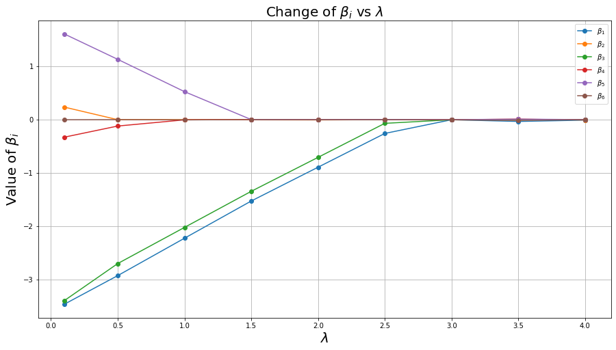

```python
#Visualisation of beta vs lambda
plt.figure(figsize=(15,8))
for i in range(1,X_train_122.shape[1]):
    plt.plot(lambdas, beta_list[i,:], marker='o', linestyle='-', label=rf"$\beta_{i}$")

plt.xlabel(r"$\lambda$", size=20)
plt.ylabel(r"Value of $\beta_i$", size=20)
plt.title(rf"Change of $\beta_i$ vs $\lambda$", size=20)
plt.grid()
plt.legend()
plt.show()
```

From our lecture notes, we know that the regularisation term $L1$ tends to encourage the model to have sparse solutions by driving some of the regression coefficients to zero, effectively removing some features from the model. This is because in order to minimise the penalty $\sum |\beta_j|$, it is worth shrinking some $\beta_j$ severely to relieve the penalty.

This can be confirmed by our plot above. When $\lambda$ is small, most coefficients are allowed too have larger magnitudes. But for large penalty, for example for $\lambda >3$, all $\beta_j$ are driven to zero aggressively. This makes sense, as the larger the $\lambda$ is, the more the penalty contributes, the more severely we need to shrink the parameters.

Different $\beta_j$ can have difference speed in converging to zero. LASSO is shrinking those feature which has low contribution to our target variable first. Referring to the inferred $\beta$ retrieved in section 1.2.1, we could tell $\beta_2, \beta_4, \beta_6$ are having low coefficients, and they are the first 3 parameters that being reeduced to zero. While $\beta_1$ and $\beta_3$ have highest coefficients, they are the last two parameters becoming zero. There is another criteria that LASSO shrinkage is based on: the correlation between parameters. If two parameters $\beta_i$ and $\beta_j$ have strong correlation in between, one of the two will be shrinked to zero quickly. As $\lambda$ increases, the penalty increases, which means the tolerance of correlated predictors are decreasing, more and more paramters are tending to zero. This is a desirable property in many cases, as it allows us to identify the most important features for predicting the response variable, by dropping redundant features. However, at the same moment as the shrinkage goes on, it gives us the bias-variance trade off.

For small $\lambda$, parameters does not change much. Thus there could be cases that some non-relevant features have large coefficients while relevant features have somme coefficients, which are overlooked. As a result, the model will fit well to our training set, but not generalize well to new data, may perform poorly on the test data. This is because the model is too complex and cannot distinguish between the signal and the noise. Therefore, we say it has a high *variance* and low *bias*.

Conversely, as the value of lambda increases, the model becomes simpler and more interpretable, and the magnitude of the inferred parameters decreases. This leads to a *reduction in variance* and an *increase in bias*. This is because the model is underfitting the training data and may be missing some important patterns in the data. However, the model is able to generalize better to new data and may perform better on the test data. The optimal regularization strength is the one that balances these two competing forces and leads to the best performance on the test data.

1.2.3

Now I use our optimal hyper-parameters to predict the sound pressure in our testset *airfoil_test*.

```python
#Optimal paramether from 1.2.1
opt_lasso_penalty =  0.0012648552168552957

ysp_train_predict123 = lasso_predict(Xsp_train_aug, ysp_train, Xsp_train_aug, opt_lasso_penalty, constmul=12)
ysp_test_predict123 = lasso_predict(Xsp_train_aug, ysp_train, Xsp_test_aug, opt_lasso_penalty, constmul=12)

print("---Results for 1.2.3---")
print("In-sample MSE: ", MSE(ysp_train, ysp_train_predict123))
print("In-sample r2 score: ", r2_score(ysp_train, ysp_train_predict123))

print("-----------------------")
print("Out-sample MSE: ", MSE(ysp_test, ysp_test_predict123))
print("Out-sample r2 score: ", r2_score(ysp_test, ysp_test_predict123))
```

```
---Results for 1.2.3---
In-sample MSE:  1.8755680778025081
In-sample r2 score:  0.9177338960260171
-----------------------
Out-sample MSE:  2.0031288219625396
Out-sample r2 score:  0.9074514554925623
```

It follows the same pattern as section 1.1.2. Out-of-sample has slightly higher MSE and lower $R^2$ score. This is expected as the model is not penalised by LASSO much, similar parameters are returned. However, out-of-sample has approximately 0.91 as $R^2$ score, indicating that out fitting is still good.

Next I will generate a plot demonstrating the comparison between the performace when $\lambda=0$ and $\lambda = 0.001 $, optimal found in 1.2.1 (although it is almost zero as well).

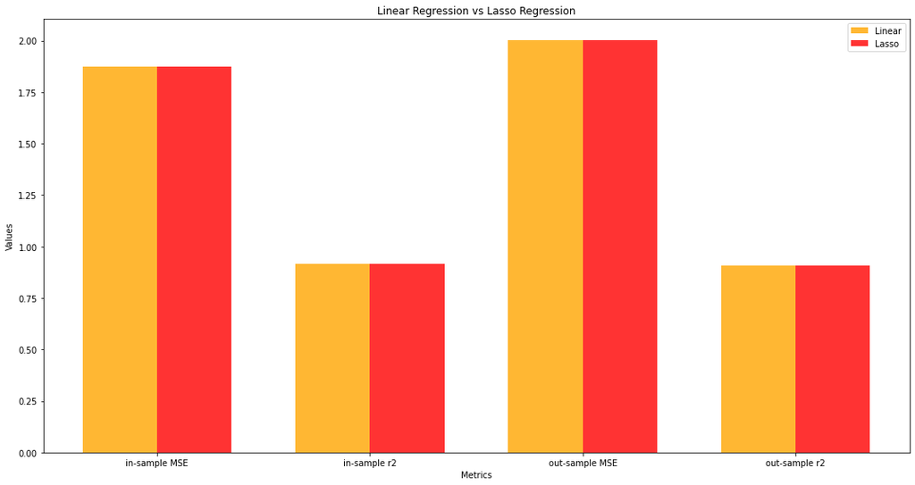

```python
linear_in_mse = MSE(ysp_train, ysp_predict111)
linear_in_r2 = r2_score(ysp_train, ysp_predict111)
linear_out_mse = MSE(ysp_test, ysp_predict112)
linear_out_r2 = r2_score(ysp_test, ysp_predict112)

lasso_in_mse = MSE(ysp_train, ysp_train_predict123)
lasso_in_r2 = r2_score(ysp_train, ysp_train_predict123)
lasso_out_mse = MSE(ysp_test, ysp_test_predict123)
lasso_out_r2 = r2_score(ysp_test, ysp_test_predict123)

fig, ax = plt.subplots(figsize=(15, 8))
bar_width = 0.35
opacity = 0.8

# create the bars for in-sample performance
in_labels = ['in-sample MSE', 'in-sample r2']
linear_in_values = [linear_in_mse, linear_in_r2]
lasso_in_values = [lasso_in_mse, lasso_in_r2]
in_bar_positions = np.arange(len(in_labels))
ax.bar(in_bar_positions - bar_width/2, linear_in_values, bar_width, alpha=opacity, color='orange', label='Linear')
ax.bar(in_bar_positions + bar_width/2, lasso_in_values, bar_width, alpha=opacity, color='red', label='Lasso')

# create the bars for out-sample performance
out_labels = ['out-sample MSE', 'out-sample r2']
linear_out_values = [linear_out_mse, linear_out_r2]
lasso_out_values = [lasso_out_mse, lasso_out_r2]
out_bar_positions = np.arange(len(out_labels)) + len(in_labels)
ax.bar(out_bar_positions - bar_width/2, linear_out_values, bar_width, alpha=opacity, color='orange', label='_nolegend_')
ax.bar(out_bar_positions + bar_width/2, lasso_out_values, bar_width, alpha=opacity, color='red', label='_nolegend_')

# set the axis labels and legend
ax.set_xticks(np.arange(len(in_labels) + len(out_labels)))
ax.set_xticklabels(in_labels + out_labels)
ax.set_xlabel('Metrics')
ax.set_ylabel('Values')
ax.set_title('Linear Regression vs Lasso Regression')
ax.legend(loc='upper right', framealpha=0.8)

# show the plot
plt.tight_layout()
plt.show()
```

Our plot shows that the lasso and linear regression ($\lambda$ = 0 is equivalent to the loss function in section 1.2.1) are perfoming the same both in in-sample and out-sample cases. This is because our dataset is not really suitable for $L1$ regularisation, and our optimal $\lambda$ is extremely small, the penalty term has little effect in estimating parameters.

In general, for some non-trivial $\lambda$, we could expect the in-sample MSE ($R^2$) of lasso regression get higher(lower) compared to linear regression. Because the regularisation will avoid overfitting, as discussed in section 1.2.2, some features of original can be missed out, but as the generalisation has been taken care of, lasso should have large bias and small variance, the out-of-sample MSE($R^2$) should be lower(higher) than linear regression.

#### 1.3 Elastic Nets (20 marks)

1.3.1

In this question, I implement the elastic net linear regression by minimising the loss function $$ L_{EN}(\beta)=\frac{1}{2N} \|y - X'\beta'\|_2^2 + \lambda ( \alpha \|\beta\|_1 + (1 - \alpha)\|\beta\|_2^2) $$ Notice that I write the first 2-norm in the augmented matrix form as I did in lasso regression. The 1-norm and second 2-norm leave as $\beta$ rather than $\beta'$ because the regularisation is not applied to the intercept term.

As I have presented carefully the derivative of $\|x\|_2^2$ and the 'hack' to the derivative of 1-norm in section 1.2.1, I will now write down the derivative of $L_{EN}$ w.r.t $\beta$ directly: $$ \frac{\partial L}{\partial \beta} = \frac{1}{N} (-X^T) (y - X'\beta') + \lambda (\alpha \cdot sign(\beta) + 2(1-\alpha)\beta) $$ As I have performed a massive grid search for the constant multiplier of learning rate in section 1.2, now for simiplity, I will stick to the optimal constant multiplier of lasso regression in this section.

```python
def elastic_net_estimate(X, y, lambda_, alpha, max_iter=100000, tolerance=1e-7, constmul=12):
    """
    Estimate coefficients for the Elastic Net model using Gradient Descent with L1 and L2 regularization.

    :param X: (N, M) matrix, predictor sets
    :param y: (N, 1) array, target vector
    :param lambda_: float, penalty parameter controlling the strength of the regularization.
    :param alpha: float, parameter controlling the trade-off between the L1 and L2 penalties.
    :param max_iter: maximum number of iterations for Gradient Descent
    :param tolerance: float, tolerance to convergence of gradient descent
    :param constmul: constant multiplier of the learning rate.

    :return beta: (M, 1) array of coefficients for the model.
    """

    N, M = X.shape
    # Initialize beta to zero, and set initial loss at a low value
    beta, old_loss = np.zeros(M), 0

    for niter in range(1, max_iter+1):
        # Compute the loss
        loss = 1 / (2*N) * np.linalg.norm(y - X @ beta)**2 + lambda_ *\
            (alpha * np.sum(np.sqrt(beta[1:]**2)) + (1 - alpha) * np.linalg.norm(beta[1:])**2)
        # Terminate the function if percentage loss is less than tolerance
        if abs(loss - old_loss) < tolerance * old_loss:
            break
        old_loss = loss

        #Update gradient base on derivative of loss function
        grad_beta = -1/N * X.T @ (y - X @ beta)
        grad_beta[1:] += lambda_ * (alpha * np.sign(beta[1:]) + 2 * (1 - alpha) * beta[1:])

        # Update beta
        beta -= constmul/ niter * grad_beta

    return beta
```

1.3.2

Hereby I implement 5 functions to perform the prediction, scoring, cross validation, and grid search for hyper-parameters $\lambda$ and $\alpha$ respectively.

```python
def elastic_net_predict(X_train, y_train, X_test, lambda_, alpha, constmul=12):
    """
    Make predictions using Elastic Net Regression with given lambda and alpha penalties.

    :param X_train: (N, M) numpy array, predictors in training set
    :param y_train: (N, 1) numpy array, target variable in training set
    :param X_test: (N', M) numpy array, predictors in test set
    :param lambda_: float, penalty of lasso, hyper-parameter
    :param constmul: float, the constant multiple of learning rate, default 10

    :return: y_pred (N', 1) numpy array, predicted target values using Lasso Regression
    """
    #Obtain coefficients from training set
    beta = elastic_net_estimate(X_train, y_train, lambda_, alpha)
    #Fit our model to test set
    y_pred = X_test @ beta

    return y_pred

def elastic_net_score(X_train, y_train, X_test, y_test, lambda_, alpha, constmul=12):
    """
    Calculates the mean squared error (MSE) of elastic net regression on the test data.

    :param X_train: (N, M) numpy array, training predictors set
    :param y_train: (N, 1) numpy array, training target variable
    :param X_test: (N', M) numpy array, test predictors set
    :param y_test: (N', 1) numpy array, test target variable
    :param lambda_: float, penalty of lasso, hyper-parameter
    :param constmul: float, optional, constant multiplier for gradient descent step size

    :return mse: float, MSE score of our fitting
    """
    #Fit our model to test predictors
    y_pred = elastic_net_predict(X_train, y_train, X_test, lambda_, alpha)

    return MSE(y_test, y_pred)

def elastic_net_cross_validation_score(X_train, y_train, fold, lambda_, alpha):
    """
    Perform T-fold cross validation on elastic net regression.

    :param X_train: (M, D) numpy array, training set
    :param y_train: (M, 1) numpy array, target variable for training set
    :param fold: int, number of folds
    :param lambda_: float, strength of the regularisation
    :param alpha: float, relative importance of the ridge and lasso terms

    :return: float, average of MSE of all folds
    """
    # Initialize an empty list to store the scores from each fold
    scores = []

    # Divide the training data into T folds
    folds = np.split(np.arange(len(y_train)), fold)

    p = np.random.permutation(len(y_train))
    X_train = X_train[p]
    y_train = y_train[p]

    # Loop over each fold
    for i in range(len(folds)):
        # Get the validation index for this fold
        val_indexes = folds[i]
        # Get the training index for this fold
        train_indexes = list(set(range(y_train.shape[0])) - set(val_indexes))

        # Get the training data for this fold
        X_train_i = X_train[train_indexes, :]
        y_train_i = y_train[train_indexes]

        # Get the validation data for this fold
        X_val_i = X_train[val_indexes, :]
        y_val_i = y_train[val_indexes]

        # Calculate the score for this fold using the score function
        score_i = elastic_net_score(X_train_i, y_train_i, X_val_i, y_val_i, lambda_, alpha)
        # Add the score to the list of scores
        scores.append(score_i)

    # Return the average score
    return np.mean(scores)

def elastic_net_choose_best_lambda(X_train, y_train, folds, lambda_range, alpha):
    """
    Find the lambda value that results in the lowest mean squared error under a fixed alpha
    when performing T-fold cross-validation.

    :param X_train: (M, D) array, training set
    :param y_train: (M, 1) array, the classifications of X_train
    :param fold: integer, number of folds for cross-validation
    :param lambda_: float, strength of the regularisation
    :param alpha: float, relative importance of the ridge and lasso terms

    :return best_lambda: lambda value that resulted in the lowest mean squared error
    :return best_score: the corresponding mean squared error
    :return all_scores: array containing the mean squared errors for all values of lambda in lambda_range
    """
    #Initialise set to record the MSE under each lambda
    lambda_scores = np.zeros(len(lambda_range))

    #Loop over each lambda
    for i, lambda_ in enumerate(lambda_range):
        lambda_scores[i] = elastic_net_cross_validation_score(X_train, y_train, folds, lambda_, alpha)

    #Find the index of lambda giving the least average MSE
    best_lambda_index = np.argmin(lambda_scores)

    return lambda_range[best_lambda_index], lambda_scores[best_lambda_index], lambda_scores


def elastic_net_grid_search(X_train, y_train, X_test, y_test, fold, lambda_range, alpha_range):
    """
    Performs a grid search to find the best combination of hyperparameters for elastic net regression,
    by testing every combination of penalty parameters lambda and alpha in the provided ranges,
    Use the optimal parameters to fit the test dataset and generate out-of-sample mse and r2 score.

    :param X_train: (M, D) array, training set
    :param y_train: (M, 1) array, the classifications of X_train
    :param fold: integer, number of folds to use in cross-validation
    :param lambda_range: list of strength of the regularisation
    :param alpha: list of relative importance of L1 and L2 regularisation

    """
    #Evaluate r2 score and MSE for each combination
    r2_array, mse_array = np.zeros((len(alpha_range), len(lambda_range))), np.zeros((len(alpha_range), len(lambda_range)))
    for i, alpha in enumerate(alpha_range):
        for j, lambda_ in enumerate(lambda_range):
            #Predict base on test set using trained model
            y_pred = elastic_net_predict(X_train, y_train, X_test, lambda_, alpha)
            r2_array[i,j] = r2_score(y_test, y_pred)
            mse_array[i,j] = MSE(y_test, y_pred)

    fig, (ax1, ax2) = plt.subplots(nrows=1, ncols=2, figsize=(15,8))
    #Create a heatmap of the out-of-sample MSE values
    im1 = ax1.imshow(mse_array, cmap='hot', interpolation='nearest', aspect='auto',
                     extent=(lambda_range.min(), lambda_range.max(), alpha_range.min(), alpha_range.max()))
    ax1.set_xlabel('Lambda')
    ax1.set_ylabel('Alpha')
    ax1.set_title('Heat map of MSE score')
    fig.colorbar(im1, ax=ax1)
    #Create a heatmap of the out-of-sample R^2 values
    im2 = ax2.imshow(r2_array, cmap='hot', interpolation='nearest', aspect='auto',
                     extent=(lambda_range.min(), lambda_range.max(), alpha_range.min(), alpha_range.max()))
    ax2.set_xlabel('Lambda')
    ax2.set_ylabel('Alpha')
    ax2.set_title('Heat map of R^2 score')
    fig.colorbar(im2, ax=ax2)

    fig.tight_layout()
    plt.show()

    #Initialise array to store score and best lambda for each alpha
    score_array, best_lambda_array = np.zeros(len(alpha_range)), np.zeros(len(alpha_range))

    #Loop over the alpha list
    for i, alpha in enumerate(alpha_range):
        #Search for the optimal lambda through cross validation
        best_lambda, best_scores, all_scores = elastic_net_choose_best_lambda(Xsp_train_aug, ysp_train, 5, lambda_range, alpha)
        #Predict on test set using optimal model
        y_pred = elastic_net_predict(X_train, y_train, X_test, best_lambda, alpha)
        print(f"---Model evaluation for alpha = {alpha}---")
        print(f"Optimal strength parameter lambda: {best_lambda}")
        print(f"Out-of-sample MSE score: {MSE(y_test, y_pred)}")
        print(f"Out-of-sample R2 score: {r2_score(y_test, y_pred)}")
        #Store the best lambda and resulting MSE score
        best_lambda_array[i] = best_lambda
        score_array[i] = best_scores
    print("Grid search all finished.")
```

Now, we are equipped with everything we need to conduct the grid search for hyper parameters. Upon request, I will scan across a chose range of $\lambda$ for $\alpha = 0.1, 0.5, 0.9$ respectively, trying to locate the optimal $\lambda$ for each.

As demonstrated in lasso regression, in our very sepcial case, a large $\lambda$ will increase the MSE by regularising to much on our training set, which is not wanted. Therefore, there is no point to test large $\lambda$ here again, instead, a smaller range $[0,0.5)$ is used as a more subtle scan list.

A 5-fold cross validation is used as required.

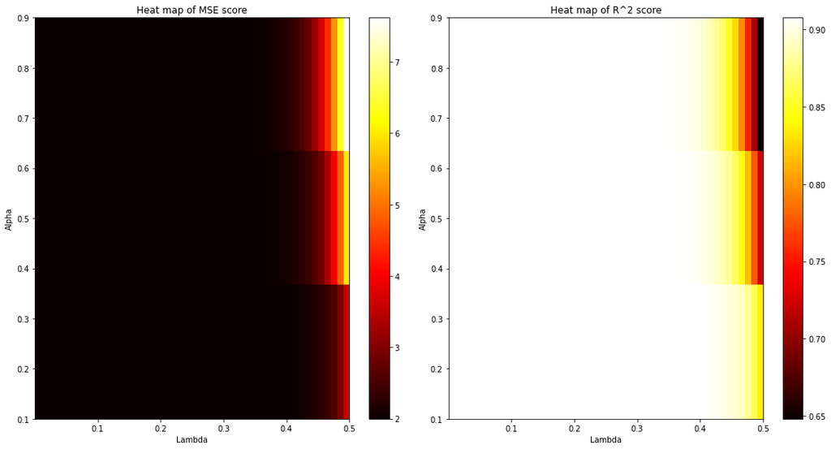

```
---Model evaluation for alpha = 0.1---
Optimal strength parameter lambda: 0.00016210953924973462
Out-of-sample MSE score: 2.0039643417947355
Out-of-sample R2 score: 0.9074128528108332
---Model evaluation for alpha = 0.5---
Optimal strength parameter lambda: 0.0002769618809532561
Out-of-sample MSE score: 2.003876485046279
Out-of-sample R2 score: 0.907416911967741
---Model evaluation for alpha = 0.9---
Optimal strength parameter lambda: 4.2489341456571486e-05
Out-of-sample MSE score: 2.004051843896249
Out-of-sample R2 score: 0.9074088100393212
Grid search all finished.
```

```python
#required values of alpha
alphas=  np.array([0.1, 0.5, 0.9])

#x is from 1e-6 to 10^(-0.30102)
lambdas = np.logspace(-6,-0.30102,50)

elastic_net_grid_search(Xsp_train_aug, ysp_train, Xsp_test_aug, ysp_test, 5, lambda_range=lambdas, alpha_range=alphas)
```

Before looking at the optimal hyper-parameters, we shall firstly focus on the two heat maps which presents the MSE and $R^2$ scores based on different combinations of $\alpha$ and $\lambda$: (The following discussion is based on our specific dataset)

From the left diagram above, we can tell MSE is largely dependent on the value of $\lambda$: for different values of $\alpha$, MSE score is lower when $\lambda$ is lower. MSE score is, to some extent, affected by $\alpha$ only when $\lambda$ is large (say $\lambda$ approaches to 0.5). As MSE indicates how well our model generalises to new data, lower $\lambda$ tends to give us a better model. Regarding the $R^2$ score, from the diagram on the right above, we can immediately see that a lower $\lambda$ leads to a higher $R^2$ score, which is good since it is a measure of how well the model fits the data. From the rightest side of $R^2$ heatmap, we can tell if we fix $\lambda$, smaller $\alpha$ tends to have larger $R^2$ score. To sum up, these two diagrams suggests that the performace of model is largely dependent on $\lambda$, while $\alpha$ only plays a relatively small part.

Now let us look at our numerical results printed. Broadly speaking, the out-of-sample performace is quite similar for different values of $\alpha$. It suggests that the choice of $\alpha$ is less critical in this case. This overlaps with what I justified from the plots: $\lambda$ affects the fitting more. The optimal $\lambda$ does vary somewhat with $\alpha$, indicating that the strength of regularisation can be influenced by the choice of $\alpha$. However, in three cases, $\lambda$ is always very small. This once again coincides with my statement from the plots that smaller $\lambda$ gives better fit in our case.

Base on the three metrics, I claim $\alpha=0.5$ provides the best model. Because it has the highest $R^2$ score and lowest MSE score at the same time, though only in a tiny difference, they are still quite good signs for a good model.

1.3.3

In this section I will explore the change of inferred parameter $\beta$ across a range of $\alpha$.

In section 1.3.2, I found the optimal $\lambda$ for three distinct $\alpha$, they are all different but essentially they are quite close to each other, with difference less than $1e-3$.

For simiplicity, I will fix the $\lambda = 0.0002769618809532561$ which is our optimal $\lambda$ for optimal $\alpha=0.5$.

Next I generate plots to demonstrate the values of inferred parameters under optimal $\lambda$ for each $\alpha=0.1, 0.5, 0.9$.

```python
#Define the optimal lambda from section 1.3.2
lambda_01 = 0.00016210953924973462
lambda_05 = 0.0002769618809532561
lambda_09 = 4.2489341456571486e-05

#Estimate our parameters for each alpha and optimal lambda
beta_01 = elastic_net_estimate(Xsp_train_aug, ysp_train, lambda_01, 0.1)
beta_05 = elastic_net_estimate(Xsp_train_aug, ysp_train, lambda_05, 0.5)
beta_09 = elastic_net_estimate(Xsp_train_aug, ysp_train, lambda_09, 0.9)
```

[figure not shown]

```python
#Visualition of parameters
#Set the positions of the bars on the x-axis
x_pos = np.arange(len(beta_01)-1)
#Set the width of each bar
bar_width = 0.3

#Create the figure and axis objects
fig, axs = plt.subplots(1, 2, figsize=(20, 8))

#Create the first bar chart
axs[0].bar(x_pos, beta_01[1:], width=bar_width, color='b', label=r'$\alpha$=0(ridge)')
axs[0].bar(x_pos + bar_width, beta_05[1:], width=bar_width, color='orange', label=r'$\alpha$=0.5(elastic net)')
axs[0].bar(x_pos + 2 * bar_width, beta_09[1:], width=bar_width, color='r', label=r'$\alpha$=1(lasso)')
axs[0].set_xlabel(r'$\beta_i$', size='20')
axs[0].set_ylabel('Value', size='20')
axs[0].set_title(rf'Bar Chart of $\beta$', size='20')
axs[0].set_xticks(x_pos + bar_width)
axs[0].set_xticklabels(['1', '2', '3', '4', '5', '6'])
axs[0].legend()

#Create the second bar chart
axs[1].bar([1, 2, 3], [beta_01[0], beta_05[0], beta_09[0]], width=bar_width, color='orange', label=r'$\beta_0$')
axs[1].set_xlabel('Method', size='20')
axs[1].set_ylabel('Value', size='20')
axs[1].set_title(rf'Bar Chart of $\beta_0$', size='20')
axs[1].set_xticks([1, 2, 3])
axs[1].set_xticklabels(['Ridge', 'Elastic Net', 'Lasso'])
axs[1].legend()

#Display the plot
plt.show()
```

As the optimal $\lambda$ is nearly zero in three cases, the regularisation barely has any effect on estimating parameters. Therefore, we can expect all the parameters are the same in these cases, as they indeed are. The magnitude of each $\beta_j$ is barely shrinked due to the smalle $\lambda$.

Value of $\beta_0$ will always be the same because the regularisation does not apply to it.

Next, I will examine the parameters under

1. $\alpha=0$: this is equivalent to a ridge regression with hyper-parameter $\lambda$
2. $\alpha=0.5$: this is an elastic net regression with regularisation strength $\lambda$ and relative strength coefficient $0.5$
3. $\alpha=1$: this is a lasso regression with hyper-parameter $\lambda$

Thus this question is equivalent to compare the effect on parameters of ridge, elastic net and lasso regression. To make the comparison meaningful and non-trivial, I choose to set $\lambda=0.5$ to at least demonstrate some effect of different penalty terms.

```python
#Estimate our parameters for each alpha (lambda=0.5)
beta_00 = elastic_net_estimate(Xsp_train_aug, ysp_train, 0.5, 0)
beta_055 = elastic_net_estimate(Xsp_train_aug, ysp_train, 0.5, 0.5)
beta_10 = elastic_net_estimate(Xsp_train_aug, ysp_train, 0.5, 1)
```

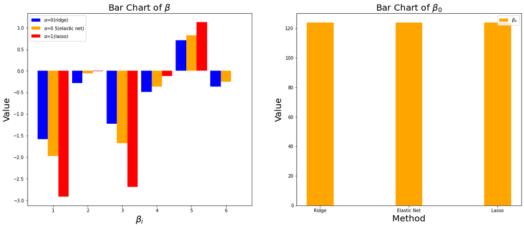

```python
# Set the positions of the bars on the x-axis
x_pos = np.arange(len(beta_01)-1)

# Set the width of each bar
bar_width = 0.3

# Create the figure and axis objects
fig, axs = plt.subplots(1, 2, figsize=(20, 8))

# Create the first bar chart
axs[0].bar(x_pos, beta_00[1:], width=bar_width, color='b', label=r'$\alpha$=0(ridge)')
axs[0].bar(x_pos + bar_width, beta_055[1:], width=bar_width, color='orange', label=r'$\alpha$=0.5(elastic net)')
axs[0].bar(x_pos + 2 * bar_width, beta_10[1:], width=bar_width, color='r', label=r'$\alpha$=1(lasso)')
axs[0].set_xlabel(r'$\beta_i$', size='20')
axs[0].set_ylabel('Value', size='20')
axs[0].set_title(r'Bar Chart of $\beta$', size='20')
axs[0].set_xticks(x_pos + bar_width)
axs[0].set_xticklabels(['1', '2', '3', '4', '5', '6'])
axs[0].legend()

# Create the second bar chart
axs[1].bar([1, 2, 3], [beta_00[0], beta_055[0], beta_10[0]], width=bar_width, color='orange', label=r'$\beta_0$')
axs[1].set_xlabel('Method', size='20')
axs[1].set_ylabel('Value', size='20')
axs[1].set_title(r'Bar Chart of $\beta_0$', size='20')
axs[1].set_xticks([1, 2, 3])
axs[1].set_xticklabels(['Ridge', 'Elastic Net', 'Lasso'])
axs[1].legend()

# Display the plot
plt.show()
```

In ridge regression, the penalty term is proportional to the squared magnitude of the coefficients, which is $\lambda\|\beta\|_2^2$. To minimise this penalty term, ridge regression skrinks $\beta_j$ towards zero, but unlike lasso, it will not necessarily set $\beta_j$ exactly to zero. This is because if $\beta_j$ is tiny already, $\beta_j^2$ has even less effect to the penalty, ridge will stop shrinking it at some point. Likewise, when $\beta_j$ is large, it will be shrinked heavily. This can be confirmed by the plot above, remember $\beta_1, \beta_3, \beta_5$ are larger than the others, and ridge indeed shrinks them heavier than Lasso and Elastic net do.

There is a second explanantion of the shrinkage of ridge regression, let us consider the SVD of $X$, such that $X=U D V^{\top}$, and by lecture notes, we know $\hat{\beta}^{\text {ridge }}=\left(X^{\top} X+\lambda I\right)^{-1} X^{\top} y$. Firstly,

$$ X^{\top} X=V D^{\top} U^{\top} U D V^{\top}=V D^{\top} D V^{\top}=V D^2 V^{\top} $$

then, $$ X \hat{\beta}^{\text {ridge }} =\left(U D V^{\top}\right)\left(V D^{\top} D V^{\top}+\lambda I\right)^{-1}\left(V D^{\top} U^{\top}\right) Y =\sum_{j=1}^p u_j \frac{d_j^2}{d_j^2+\lambda} u_j^{\top} Y $$ where $u_j$ is the $j-th$ columns of $U$ and $d_j$ is the $j-th$ diagonal element of $D$. (A few steps of deduction are omitted here as they are essentially basic linear algebra). Then it can be seen that if $d_j$ is large, then $\frac{d_j^2}{d j^2+\lambda} \approx 1$; if $d_j$ is small, $\frac{d_j^2}{d_j^2+\lambda}<1$. In the latter case, we consider less effect of $u_j$ will be transferrd to $\hat Y = X \hat \beta$, (especially for large $\lambda$), that's why ridge chooses to shrink those parameters first. In other words, ridge regression shrinks coordinates in the directions where the singular value is small.

In contrast, lasso regression introduces a penalty term proportional to the absolute magnitude of the coefficients, which is $\lambda \|\beta\|_1$. Small $\beta_j$ has little effect in L2 penalty, it can still have a few effect in L1 penalty. That is why lasso will keep shrinking it to zero, resulting in a sparse solution that performs variable selection. Likewise, large $\beta_j$ will be shrinked less compared to ridge as $\|\cdot\|_1$ contributes less than $\|\cdot\|_2^2$ in this case. Recall $\beta_1, \beta_3, \beta_5$ are larger, so ridge shrinks them more than lasso does, while $\beta_2, \beta_4, \beta_6$ are small, lasso directlt sets them to (almost) zero. This lasso shrinkage will also first applies to those predictors have correlation with other predictors. In general, lasso regression will produce fewer non-zero coefficients than ridge regression.

In summary, ridge regression will shrink all the coefficients but not to zero, lasso regression will produce some coefficients that are exactly zero, and elastic net regression will perform a combination of shrinkage and variable selection.

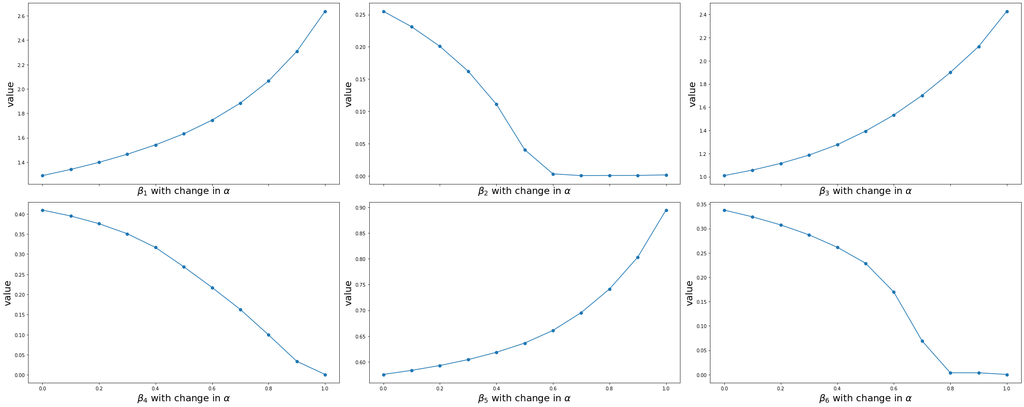

```python
lambda_ = 0.7
alpha_array = np.arange(0,1.1, 0.1)
beta_array = np.zeros((11,7))

for i, alpha in enumerate(alpha_array):
    beta = elastic_net_estimate(Xsp_train_aug, ysp_train, lambda_, alpha, max_iter=100000, tolerance=1e-7, constmul=12)
    beta_array[i] = beta #ith row of beta_array is our this beta

beta_array = beta_array[:, 1:]
# Create subplots with 3 subplots in each row
fig, axs = plt.subplots(2, 3, figsize=(30, 12), sharex=True)

# Iterate over each feature and plot it
for i in range(6):
    row = i // 3
    col = i % 3
    axs[row, col].plot(alpha_array, abs(beta_array[:, i]), marker='o', linestyle='-')
    axs[row, col].set_xlabel(rf'$\beta_{i+1}$ with change in $\alpha$', fontsize=20)
    axs[row, col].set_ylabel('value', fontsize=20)

# Remove any unused subplots
if 6 % 3 != 0:
    for i in range(3 - (6 % 3)):
        fig.delaxes(axs[-1, -(i + 1)])

# Adjust spacing and layout
fig.tight_layout()

# Show the plot
plt.show()
```

As inferred $\beta_2, \beta_4, \beta_6$ are small, as $\alpha$ increases, effect of $L1$ penalty (lasso penalty) increases, they are shirnked heavier all the way to zero. Meanwhile, larer values of $\beta_1, \beta_3, \beta_5$ are getting a relief from the case $\alpha=0$ where the effect of $L2$ penalty is the most. These trends are in line with my justification above.

#### 1.4 kNN regression (10 marks)

1.4.1

In this section, I perform the K-Nearest Neighbourhood regression. The neighbours are defined by the distance between the feature values of each data point, and in this coursework, the distance is calculated by Euclidean distance. Once the k closest neighbors are identified, KNN regression calculates the average value of the target variable for these k neighbors. This average value is then used as the predicted value for the new data point. (In weekly exercise, $R^2$ score is used in cross validation for KNN, yet here MSE is chosen as the next section requires to test and compare out-of-sample MSE.)

```python
def euclidean_distance(p, q):
    """
    Find Euclidean distance between two sets of points

    :param p, q: k x D np arrays, represents k points in D-dimensional space

    :return d: 1d array of length k, distances
    """
    return np.sqrt(np.sum((p-q)**2, axis=1))

def k_neighbours(X_train, X_test, k=5, return_distance=False):
    """
    Given training and testing set,

    :param X_train: M x D np array, training set
    :param X_test: N x D np array, testing set
    :param k: hyper-parameter, 5 by default
    :param return_distance: boolean, if true, return the distances for k nearest neighbours

    :return neigh_ind: N x k np array, indices of k nearest neighrbous
    :return dist: N x k np array, indices of k nearest neighrbous
    """
    n_neighbours = k
    dist = []
    neigh_ind = []

    # compute distance from each point x_text in X_test to all points in X_train
    point_dist = [euclidean_distance(x_test, X_train) for x_test in X_test]

    # determine which k training points are closest to each test point
    for row in point_dist:
        enum_neigh = enumerate(row)
        sorted_neigh = sorted(enum_neigh, key=lambda x: x[1])[:k]

        ind_list = [tup[0] for tup in sorted_neigh]
        dist_list = [tup[1] for tup in sorted_neigh]

        dist.append(dist_list)
        neigh_ind.append(ind_list)

    # return distances together with indices of k nearest neighbouts
    if return_distance:
        return np.array(dist), np.array(neigh_ind)

    return np.array(neigh_ind)

def reg_predict(X_train, y_train, X_test, k=20):
  """
  Predict y-value based on values of k nearest neighbours
  with equal weights

  :param X_train: M x D np array, training set
  :param y_train: 1d array of length M, the classifications of X_train
  :param X_test: N x D np array, testing set
  :param k: hyper-parameter, 20 by default

  :return y_pred: 1d array of length N, the predicted classifications of X_test
  """
  # each of the k neighbours contributes equally to the classification of any data point in X_test
  neighbours = k_neighbours(X_train, X_test, k=k)
  # compute mean over neighbours labels
  y_pred = np.array([np.mean(y_train[neighbour]) for neighbour in neighbours])

  return y_pred

def knn_score(X_train, y_train, X_test, y_test, k):
    """
    Calculate the mean squared error (MSE) between the predicted values and the true values
    for a k-nearest neighbor regression model.

    :param X_train: the training data features
    :param y_train: the training data target values
    :param X_test: the test data features
    :param y_test: the test data target values
    :param k: the number of nearest neighbours to consider

    :return: mse: mean square error between the predicted values and the true values
    """

    # Use the reg_predict function to get the predicted values
    y_pred = reg_predict(X_train, y_train, X_test, k)

    # Calculate the mean squared error between the predicted and true values
    return MSE(y_test, y_pred)


def knn_cross_validation_score(X_train, y_train, fold, k):
    """
    Perform k-fold cross validation for a k-nearest neighbor regression model.

    :param X_train: the training data features
    :param y_train: the training data target values
    :param fold: the number of folds to use for cross validation
    :param k: the number of nearest neighbours to consider

    :return float: average mean squared error of cross validation
    """

    # Initialize an empty list to store the scores from each fold
    scores = []

    # Divide the training data into T folds
    folds = np.split(np.arange(len(y_train)), fold)
    p = np.random.permutation(len(y_train))
    X_train = X_train[p]
    y_train = y_train[p]

    # Loop over each fold
    for i in range(len(folds)):
        # Get the validation index for this fold
        val_indexes = folds[i]
        # Get the training index for this fold
        train_indexes = list(set(range(y_train.shape[0])) - set(val_indexes))

        # Get the training data for this fold
        X_train_i = X_train[train_indexes, :]
        y_train_i = y_train[train_indexes]

        # Get the validation data for this fold
        X_val_i = X_train[val_indexes, :]
        y_val_i = y_train[val_indexes]

        # Calculate the score for this fold using the score function
        score_i = knn_score(X_train_i, y_train_i, X_val_i, y_val_i, k)
        # Add the score to the list of scores
        scores.append(score_i)

    # Return the average score
    return np.mean(scores)
```

Here a grid search function is used to scan across a range of K values by calling a 5-fold cross validation function.

```python
def knn_grid_search(X_train, y_train, folds, k_range):
    """
    Givin lambda_range, list of lambda to test, find the best T-fold score

    :param X_train: M x D np array, training set
    :param y_train: 1d array of length M, the classifications of X_train
    :param folds: T x (M/T) array, each row are fold indices
    :param lambda_range: list of values of lambda to test

    :return best_k: best k value in k_range
    """
    k_scores = np.zeros((len(k_range),))

    print('Grid search in progress...')
    for i, k in enumerate(k_range):
        k_scores[i] = knn_cross_validation_score(X_train, y_train, folds, k)
    print('Grid search all finished.')

    best_k = k_range[np.argmin(k_scores)]
    best_score = np.min(k_scores)

    plt.figure(figsize=(15,8))
    plt.semilogy(k_range, k_scores)
    plt.scatter(best_k, best_score, c='#d62728')
    plt.xlabel(r"values of k", size=20)
    plt.ylabel(r"Cross validation (MSE) score", size=20)
    plt.title(r"Grid search of k for 1.4.1")
    plt.grid()
    plt.show()

    print("-----------------------------------------------------------------")
    print(f"---Optimal hyper parameters of KNN regression k is: {best_k}")
    print(f"resulting cross validation score is: {best_score}")

    return best_k, best_score
```

I choose to scan through $K \in [1,30]$, and find the one giving least average MSE scores.

```
Grid search in progress...
Grid search all finished.
```

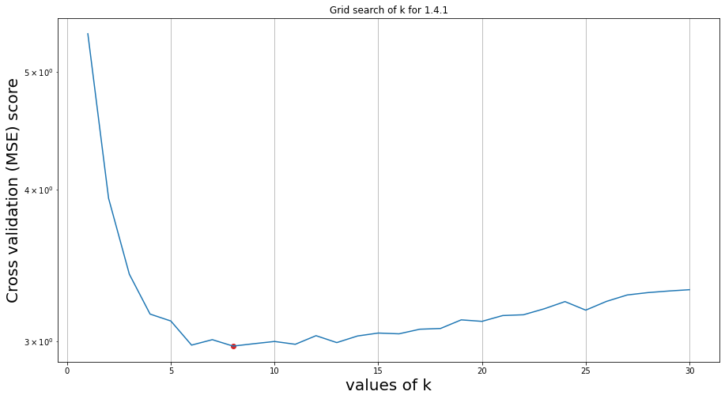

```
-----------------------------------------------------------------
---Optimal hyper parameters of KNN regression k is: 8
resulting cross validation score is: 2.9713173703095057
```

```python
k_range = np.arange(1,31)
best_k, best_knn_score = knn_grid_search(Xsp_train_aug, ysp_train, 5, k_range)
```

As the plot demonstrates, the 8-Nearest Neighbourhood model gives us the best fitting of our dataset by having a average MSE at 2.97. It means that on average, the predicted values are 2.97 units away from the true values.

1.4.2

In this section, I fix the K at the optimal value, and use it to train our full dataset *airfoil_sample* and then predict on *airfoil_test* dataframe

```python
y_pred142 = reg_predict(Xsp_train_aug, ysp_train, Xsp_test_aug, k=8)
```

Now I will summarise all the out-of-sample MSE found by 4 different methods in this task.

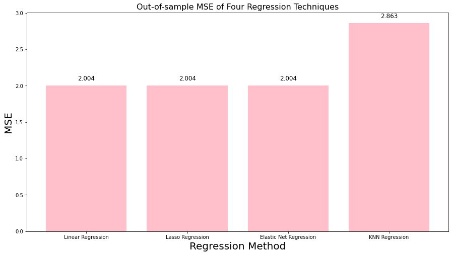

```python
#MSE of different methods
mse_111 = MSE(ysp_test, ysp_predict112)
mse_123 = MSE(ysp_test, ysp_test_predict123)
mse_132 = MSE(ysp_test, elastic_net_predict(Xsp_train_aug, ysp_train, Xsp_test_aug, lambda_= 0.0002769618809532561, alpha=0.5, constmul=12))
mse_142 = MSE(ysp_test, y_pred142)

mse_values = [mse_111, mse_123, mse_132, mse_142]
methods = ['Linear Regression', 'Lasso Regression', 'Elastic Net Regression', 'KNN Regression']

# Create the figure and axes
fig, ax = plt.subplots(figsize=(15, 8))

# Create the bar chart
bars = ax.bar(methods, mse_values, color='pink')

# Set the title and axis labels
ax.set_title('Out-of-sample MSE of Four Regression Techniques', fontsize=16)
ax.set_xlabel('Regression Method', fontsize=20)
ax.set_ylabel('MSE', fontsize=20)

# Add the values on top of the bars
for bar, mse in zip(bars, mse_values):
    ax.text(bar.get_x() + bar.get_width() / 2, bar.get_height() + 0.05, f'{mse:.3f}', ha='center', va='bottom', fontsize=12)

plt.show()
```

This is very obvious that KNN is having the hightest MSE score on fitting the test dataframe. All three other methods are having the same (to 4 digits of significance) MSE score, although it is caused by our training set is not suitable for neither lasso nor elastic net which gives zero as optimal $\lambda$.

The result is suggesting that there is a strong linear relationship between the predictors and the outcome. This is because KNN regression is a non-parametric method, meaning that it makes no assumptions about the functional form of the relationship between the predictors and the outcome. Instead, it estimates the relationship based on the similarity between the predictor values of the training instances and the predictor values of the test instances. In contrast, linear regression, lasso regression, and elastic net regression are all linear models, meaning that they assume a linear relationship between the predictors and the outcome. They estimate the coefficients of the linear model based on the training data, and use these coefficients to predict the outcome for new instances.

Therefore, if the relationship between the predictors and the outcomes is non-linear, KNN should perform better than the other three linear models. In our case, it is on the contrary, KNN is worst, saying that the liner relationship is significant. However, it's also possible that the poor performance of KNN regression is due to overfitting to noise in the training data, by lecture notes, KNN is sensitive to the dimensionality of the data.

## Task 2: Classification (50 marks)

### Data loading, cleaning and visualisation

In this task, we try to classify the dataset *diabetes_samples* using random forest, and test our model on dataset *diabetes_test*. This task is essential trying to identify as many diabetic patients as possible in both training and test sets.

As usual, we start with loading our training dataframe *diabetes_sample*.

```python
#Load training dataframe
diabetes_sample = pd.read_csv('diabetes_samples.csv')
#Visualise frist ten rows
diabetes_sample.head(10)
```

|  | patient_number | cholesterol | glucose | hdl_chol | chol_hdl_ratio | age | height | weight | bmi | systolic_bp | diastolic_bp | waist | hip | waist_hip_ratio | diabetes |
| --- | --- | --- | --- | --- | --- | --- | --- | --- | --- | --- | --- | --- | --- | --- | --- |
| 0 | 115 | 224 | 85 | 30 | 7,5 | 36 | 69 | 205 | 30,3 | 150 | 99 | 37 | 41 | 0,9 | No diabetes |
| 1 | 318 | 194 | 95 | 36 | 5,4 | 63 | 58 | 210 | 43,9 | 140 | 100 | 44 | 53 | 0,83 | No diabetes |
| 2 | 73 | 207 | 75 | 44 | 4,7 | 30 | 72 | 180 | 24,4 | 118 | 62 | 35 | 41 | 0,85 | No diabetes |
| 3 | 69 | 144 | 81 | 28 | 5,1 | 30 | 72 | 165 | 22,4 | 118 | 78 | 31 | 38 | 0,82 | No diabetes |
| 4 | 326 | 181 | 177 | 24 | 7,5 | 64 | 71 | 225 | 31,4 | 130 | 66 | 44 | 47 | 0,94 | Diabetes |
| 5 | 148 | 219 | 105 | 63 | 3,5 | 40 | 62 | 153 | 28 | 106 | 82 | 36 | 44 | 0,82 | No diabetes |
| 6 | 204 | 190 | 107 | 32 | 5,9 | 46 | 72 | 205 | 27,8 | 145 | 88 | 46 | 49 | 0,94 | No diabetes |
| 7 | 251 | 196 | 120 | 67 | 2,9 | 52 | 62 | 147 | 26,9 | 144 | 94 | 34 | 42 | 0,81 | Diabetes |
| 8 | 161 | 184 | 79 | 39 | 4,7 | 41 | 69 | 154 | 22,7 | 136 | 96 | 34 | 39 | 0,87 | No diabetes |
| 9 | 389 | 232 | 184 | 114 | 2 | 91 | 61 | 127 | 24 | 170 | 82 | 35 | 38 | 0,92 | Diabetes |

We could tell our dataset is having a few issues now:

(i): It is indexed by row number, however, the data contains the column `patient_number` which is a natural and better way for indexing. So I will reset the dataframe index using patient number.

(ii). There are a few columns containing floating number, yet the way it records floating number is using comma rather than dot. I will replace it by dot following python convenction.

(iii). Last column *diabetes* contains our binary categorical outcome. Rather than dealing with a string, I will record it as -1 (No diabetes) and 1 (diabetes), which is a more pythonic way.

```python
# set column id as dataframe index
diabetes_sample = diabetes_sample.set_index(diabetes_sample['patient_number']).drop(diabetes_sample.columns[0], axis=1)

# convert categorical labels to binary numbers
diag_map = {'No diabetes': -1.0, 'Diabetes': 1.0}
diabetes_sample['diabetes'] = diabetes_sample['diabetes'].map(diag_map)

#Convert the form of floating point into a python interpretatble way
columns_to_map = ['chol_hdl_ratio', 'bmi', 'waist_hip_ratio']
diabetes_sample[columns_to_map] = diabetes_sample[columns_to_map].applymap(lambda x: float(x.replace(',', '.')))

#Check our updated dataframe
diabetes_sample.head(10)
```

| patient_number | cholesterol | glucose | hdl_chol | chol_hdl_ratio | age | height | weight | bmi | systolic_bp | diastolic_bp | waist | hip | waist_hip_ratio | diabetes |
| --- | --- | --- | --- | --- | --- | --- | --- | --- | --- | --- | --- | --- | --- | --- |
| 115 | 224 | 85 | 30 | 7.5 | 36 | 69 | 205 | 30.3 | 150 | 99 | 37 | 41 | 0.90 | -1.0 |
| 318 | 194 | 95 | 36 | 5.4 | 63 | 58 | 210 | 43.9 | 140 | 100 | 44 | 53 | 0.83 | -1.0 |
| 73 | 207 | 75 | 44 | 4.7 | 30 | 72 | 180 | 24.4 | 118 | 62 | 35 | 41 | 0.85 | -1.0 |
| 69 | 144 | 81 | 28 | 5.1 | 30 | 72 | 165 | 22.4 | 118 | 78 | 31 | 38 | 0.82 | -1.0 |
| 326 | 181 | 177 | 24 | 7.5 | 64 | 71 | 225 | 31.4 | 130 | 66 | 44 | 47 | 0.94 | 1.0 |
| 148 | 219 | 105 | 63 | 3.5 | 40 | 62 | 153 | 28.0 | 106 | 82 | 36 | 44 | 0.82 | -1.0 |
| 204 | 190 | 107 | 32 | 5.9 | 46 | 72 | 205 | 27.8 | 145 | 88 | 46 | 49 | 0.94 | -1.0 |
| 251 | 196 | 120 | 67 | 2.9 | 52 | 62 | 147 | 26.9 | 144 | 94 | 34 | 42 | 0.81 | 1.0 |
| 161 | 184 | 79 | 39 | 4.7 | 41 | 69 | 154 | 22.7 | 136 | 96 | 34 | 39 | 0.87 | -1.0 |
| 389 | 232 | 184 | 114 | 2.0 | 91 | 61 | 127 | 24.0 | 170 | 82 | 35 | 38 | 0.92 | 1.0 |

Next, as in task 1, I will now check these columns are indeed all numerical and does not conatin any invalid values like inf/NaN.

```python
print("---------------------------------")
print("---Check for numerical columns---")
print([(column, diabetes_sample[column].dtype.kind in 'iufcb') for column in diabetes_sample.columns[:7]])
print([(column, diabetes_sample[column].dtype.kind in 'iufcb') for column in diabetes_sample.columns[7:]])

print("---------------------------------")
print("---Data inclusion of Inf/NaN---")
print(diabetes_sample.isin([np.inf, -np.inf]).any() & diabetes_sample.isnull().any())
```

```
---------------------------------
---Check for numerical columns---
[('cholesterol', True), ('glucose', True), ('hdl_chol', True), ('chol_hdl_ratio', True), ('age', True), ('height', True), ('weight', True)]
[('bmi', True), ('systolic_bp', True), ('diastolic_bp', True), ('waist', True), ('hip', True), ('waist_hip_ratio', True), ('diabetes', True)]
---------------------------------
---Data inclusion of Inf/NaN---
cholesterol        False
glucose            False
hdl_chol           False
chol_hdl_ratio     False
age                False
height             False
weight             False
bmi                False
systolic_bp        False
diastolic_bp       False
waist              False
hip                False
waist_hip_ratio    False
diabetes           False
dtype: bool
```

Now our training data set is valid and ready to proceed for the random forest classifier.

Similarily, I will perform the same cleaning and validation procedures to our test dataset as follows.

```python
diabetes_test = pd.read_csv('diabetes_test.csv')

# set column id as dataframe index
diabetes_test = diabetes_test.set_index(diabetes_test['patient_number']).drop(diabetes_test.columns[0], axis=1)
# convert categorical labels to binary numbers
diabetes_test['diabetes'] = diabetes_test['diabetes'].map(diag_map)
#Convert the form of floating point into a python interpretatble way
diabetes_test[columns_to_map] = diabetes_test[columns_to_map].applymap(lambda x: float(x.replace(',', '.')))

#Inspect our updated dataframe
print(diabetes_test.head(10))

print("---------------------------------")
print("---Check for numerical columns---")
print([(column, diabetes_sample[column].dtype.kind in 'iufcb') for column in diabetes_sample.columns[:7]])
print([(column, diabetes_sample[column].dtype.kind in 'iufcb') for column in diabetes_sample.columns[7:]])

print("---------------------------------")
print("---Data inclusion of Inf/NaN---")
diabetes_sample.isin([np.inf, -np.inf]).any() & diabetes_sample.isnull().any()
```

```
                cholesterol  glucose  hdl_chol  chol_hdl_ratio  age  height  \
patient_number
3                       217       75        54             4.0   20      67
5                       164       91        67             2.4   20      70
6                       170       69        64             2.7   20      64
8                       164       71        63             2.6   20      72
9                       230      112        64             3.6   20      67
11                      174      105       117             1.5   20      70
14                      203       84        75             2.7   21      63
17                      244       89        92             2.7   21      71
20                      172       70        36             4.8   22      64
22                      223       75        85             2.6   22      62

                weight   bmi  systolic_bp  diastolic_bp  waist  hip  \
patient_number
3                  187  29.3          110            72     40   45
5                  141  20.2          122            86     32   39
6                  161  27.6          108            70     37   40
8                  145  19.7          108            78     29   36
9                  159  24.9          100            90     31   39
11                 187  26.8          132            86     37   41
14                 142  25.2          125            85     28   39
17                 163  22.7          116            76     34   39
20                 148  25.4           90            48     35   38
22                 137  25.1          120            70     28   35

                waist_hip_ratio  diabetes
patient_number
3                          0.89      -1.0
5                          0.82      -1.0
6                          0.93      -1.0
8                          0.81      -1.0
9                          0.79      -1.0
11                         0.90      -1.0
14                         0.72      -1.0
17                         0.87      -1.0
20                         0.92      -1.0
22                         0.80      -1.0
---------------------------------
---Check for numerical columns---
[('cholesterol', True), ('glucose', True), ('hdl_chol', True), ('chol_hdl_ratio', True), ('age', True), ('height', True), ('weight', True)]
[('bmi', True), ('systolic_bp', True), ('diastolic_bp', True), ('waist', True), ('hip', True), ('waist_hip_ratio', True), ('diabetes', True)]
---------------------------------
---Data inclusion of Inf/NaN---
```

```
cholesterol        False
glucose            False
hdl_chol           False
chol_hdl_ratio     False
age                False
height             False
weight             False
bmi                False
systolic_bp        False
diastolic_bp       False
waist              False
hip                False
waist_hip_ratio    False
diabetes           False
dtype: bool
```

#### 2.1 Random forest (20 marks)

2.1.1

As before, we firstly set up our feature set and target set respectively. Although we are performing the classification task, distribution of numerical features is not too critival, we still follow the convention to standardise the data set.

```python
#shuffle the rows of diabetes_sample
diabetes_sample_shuff = diabetes_sample.iloc[np.random.permutation(len(diabetes_sample))]

#Recover X
Xdb_train = diabetes_sample_shuff[diabetes_sample_shuff.columns[:-1]]
#Standardise
Xdb_train = standardise(Xdb_train)
#Recover y
ydb_train = diabetes_sample_shuff[diabetes_sample_shuff.columns[-1]]
ydb_train = ydb_train.astype(int) #Set all entries to integer

#dictionary indicating whether the column index maps to a categorical feature or numerical
columns_dict = {index: False for index in range(Xdb_train.shape[1])} #All numerical as checked before
```

We firstly define the criteria for the split in decision trees. Here the cross-entropy is used to measure the impurity of a node in the tree, it is also considered as a information gain criterion.

As defined in the lecture notes, the cross entropy has loss function $$ CE[\pi, \hat \pi] = \sum_{q=1}^Q \pi_q(R_\alpha) \cdot log(\hat \pi_\alpha(R_\alpha)) $$ where $\pi$ is the data distribution and $\hat \pi$ is the model distribution.

By information theory, the idea behind the cross-entropy index is to measure the "surprise" or "uncertainty" associated with the probability distribution of the classes in a node. A node with a low entropy (i.e., a low degree of surprise) has a clear majority of observations belonging to one class, while a node with a high entropy has a more even distribution of observations across multiple classes, which is harder to deal with. As we are looking for a good threshold to split in desicion trees, we want to minimise CE, and this is done when the model distribution is equal to the data distribution. Therefore, we substitute $\hat \pi$ by $\pi$ in the loss function as $$ CE[\pi(R_\alpha)]= - \sum_{q=1}^Q \pi_q(R_\alpha) \cdot log(\pi_\alpha(R_\alpha)) $$ We are looking for the minimisation of such function.

```python
def ce_index(y, sample_weights):
    """
    Calculate the cross-entropy index for labels.
    :param y: vector of training labels, of shape (N,).
    :param sample_weights: weights for each samples, of shape (N,).

    :return ce: float, the cross-entropy index for y.
    """
    # Count the number of occurrences of each label
    label_weights = {yi: 0 for yi in set(y)}
    for yi, wi in zip(y, sample_weights):
        label_weights[yi] += wi
    # Calculate the total weight of all samples
    total_weight = sum(label_weights.values())

    #Calculate the cross-entropy index
    ce = 0
    for label, weight in label_weights.items():
        # Calculate the entropy of the current label
        p = weight / total_weight
        ce -= p * np.log(p)
    return ce
```

Then we use functions provided in the exercises to perform the random forest classification. The following random forest functions are all referred from the functions provided in exercises, unless stated otherwise.

```python
def split_samples(X, y, sample_weights, column, value, categorical):
    """
    Return the split of data whose column-th feature:
    1. equals value, in case `column` is categorical, or
    2. less than value, in case `column` is not categorical (i.e. numerical)

    Arguments:
        X: training features, of shape (N, D).
        y: vector of training labels, of shape (N,).
        sample_weights: weights for each samples, of shape (N,).
        column: the column of the feature for splitting.
        value: splitting threshold  the samples
        categorical: boolean value indicating whether column is a categorical variable or numerical.
    Returns:
        tuple(np.array, np.array): tuple of subsets of X splitted based on column-th value.
        tuple(np.array, np.array): tuple of subsets of y splitted based on column-th value.
        tuple(np.array, np.array): tuple of subsets of sample weights based on column-th value.
    """

    if categorical:
        left_mask =(X[:, column] == value)
    else:
        left_mask = (X[:, column] < value) #tuple of True/False

    #Take out the rows based on the True/False, ~left_mask means reverse the boolean variables in left_mask
    X_left, X_right = X[left_mask, :], X[~left_mask, :]
    y_left, y_right = y[left_mask], y[~left_mask]
    w_left, w_right  = sample_weights[left_mask], sample_weights[~left_mask]

    return (X_left, X_right), (y_left, y_right), (w_left, w_right)

def ce_split_value(X, y, sample_weights, column, categorical):
    """
    Calculate the CE-index based on `column` with the split that minimizes the CE-index.
    Arguments:
        X: training features, of shape (N, D).
        y: vector of training labels, of shape (N,).
        sample_weights: weights for each samples, of shape (N,).
        column: the column of the feature for calculating. 0 <= column < D
        categorical: boolean value indicating whether column is a categorical variable or numerical.
    Returns:
        (float, float): the resulted CE-index and the corresponding value used in splitting.
    """

    unique_vals = np.unique(X[:, column]) #already sorted

    assert len(unique_vals) > 1, f"There must be more than one distinct feature value. Given: {unique_vals}."

    ce_index_val, threshold = np.inf, None

    # split the values of i-th feature and calculate the cost
    for value in unique_vals:
        (X_l, X_r), (y_l, y_r), (w_l, w_r) = split_samples(X, y, sample_weights, column, value, categorical)

        if len(y_l) == 0 or len(y_r) == 0:
            continue

        p_left = sum(w_l)/(sum(w_l) + sum(w_r))
        p_right = 1 - p_left
        new_cost = p_left * ce_index(y_l, w_l) + p_right * ce_index(y_r, w_r)
        if new_cost < ce_index_val:
            ce_index_val, threshold = new_cost, value

    return ce_index_val, threshold

def ce_split_rf(n_features, X, y, sample_weights, columns_dict):
    """
    Choose the best feature to split according to criterion.
    Args:
        n_features: number of sampled features.
        X: training features, of shape (N, D).
        y: vector of training labels, of shape (N,).
        sample_weights: weights for each samples, of shape (N,).
        columns_dict: a dictionary mapping column indices to whether the column is categorical or numerical variable.
    Returns:
        (float, int, float): the minimized ce-index, the best feature index and value used in splitting.
    """
    columns = np.random.choice(list(columns_dict.keys()), n_features, replace=False) #Choose n_features samples from the list
    columns_dict = {c: columns_dict[c] for c in columns}

    min_ce_index, split_column, split_val = np.inf, 0, 0
    for column, categorical in columns_dict.items():
        # skip column if samples are not seperable by that column.
        if len(np.unique(X[:, column])) < 2:
            continue

        # search for the best splitting value for the given column.
        ce_index, val = ce_split_value(X, y, sample_weights, column, categorical)
        if ce_index < min_ce_index:
            min_ce_index, split_column, split_val = ce_index, column, val

    return min_ce_index, split_column, split_val
```

We classify a region of nodes by the most frequent outcome in it. The argument `sample_weights` here and in the following functions are used in this function *majority_vote*.

One way to balance data is to ask the majority vote function takes into consideration of weight of each sample, rather than weighting them equally and uniformly.

```python
def majority_vote(y, sample_weights):
    """
    Return the label which appears the most in y.
    Args:
        y: vector of training labels, of shape (N,).
        sample_weights: weights for each samples, of shape (N,).
    Returns:
        (int): the majority label
    """
    majority_label = {yi: 0 for yi in set(y)}

    for yi, wi in zip(y, sample_weights):
        majority_label[yi] += wi
    return max(majority_label, key=majority_label.get)
```

Notice the change of hyperparameter `min_samples_leaf` below. It is a stopping criterion that will stop further splits as soon as the leaf reaches the minimum, preventing overfitting. By lecture notes, the is set to $1$ for classification task.

```python
def build_tree_rf(n_features, X, y, sample_weights, columns_dict, feature_names, depth, max_depth=10, min_samples_leaf=1):
        """Build the decision tree according to the data.
        Args:
            X: (np.array) training features, of shape (N, D).
            y: (np.array) vector of training labels, of shape (N,).
            sample_weights: weights for each samples, of shape (N,).
            columns_dict: a dictionary mapping column indices to whether the column is categorical or numerical variable.
            feature_names (list): record the name of features in X in the original dataset.
            depth (int): current depth for this node.
        Returns:
            (dict): a dict denoting the decision tree (binary-tree). Each node has seven attributes:
            1. 'feature_name': The column name of the split.
            2. 'feature_index': The column index of the split.
            3. 'value': The value used for the split.
            4. 'categorical': indicator for categorical/numerical variables.
            5. 'majority_label': For leaf nodes, this stores the dominant label. Otherwise, it is None.
            6. 'left': The left sub-tree with the same structure.
            7. 'right' The right sub-tree with the same structure.
        """
        # include a clause for the cases where (i) all lables are the same, (ii) depth exceed (iii) X is too small
        if len(np.unique(y)) == 1 or depth>=max_depth or len(X)<=min_samples_leaf:
            return {'majority_label': majority_vote(y, sample_weights)}

        else:
            CE, split_index, split_val = ce_split_rf(n_features, X, y, sample_weights, columns_dict)

        # If CE is infinity, it means that samples are not seperable by the sampled features.
        if CE == np.inf:
            return {'majority_label': majority_vote(y, sample_weights)}
        categorical = columns_dict[split_index]
        (X_l, X_r), (y_l, y_r), (w_l, w_r) =  split_samples(X, y, sample_weights, split_index, split_val, categorical)
        return {
            'feature_name': feature_names[split_index],
            'feature_index': split_index,
            'value': split_val,
            'categorical': categorical,
            'majority_label': None,
            'left': build_tree_rf(n_features, X_l, y_l, w_l, columns_dict, feature_names, depth + 1, max_depth, min_samples_leaf),
            'right': build_tree_rf(n_features, X_r, y_r, w_r, columns_dict, feature_names, depth + 1, max_depth, min_samples_leaf)
        }
```

Notice that an optional parameter `bootstrap_weight` is added to funtion *train_rf*, it takes in a function to assign each $y_i$ a suitable weight, which is then assigned to the boostrapping step.

Normally bootsrapping draws $N'$ random samples for training. If a weight is not specified, it will draw sampels uniformly. Yet if the dataset is imbalanced, the majority class will also be mostly drawn, while the minority class is being ignored. Adding suitable weights is to address this issue, more of choosing weights will be discussed below.

```python
def train_rf(B, n_features, X, y,  columns_dict, max_depth = 10, sample_weights=None, bootstrap_weight=None):
    """
    Build the decision tree according to the training data.
    Args:
        B: number of decision trees.
        X: (pd.Dataframe) training features, of shape (N, D). Each X[i] is a training sample.
        y: (pd.Series) vector of training labels, of shape (N,). y[i] is the label for X[i], and each y[i] is
        an integer in the range 0 <= y[i] <= C. Here C = 1.
        columns_dict: a dictionary mapping column indices to whether the column is categorical or numerical variable.
        sample_weights: weights for each samples, of shape (N,).
        bootstrap_weight: function that compute weights for each sample
    """
    if sample_weights is None:
        #if the sample weights is not provided, we assume the samples have uniform weights
        sample_weights = np.ones(X.shape[0]) / X.shape[0]
    else:
        sample_weights = np.array(sample_weights) / np.sum(sample_weights)

    feature_names = X.columns.tolist()
    X = X.to_numpy()
    y = y.to_numpy()
    N = X.shape[0]
    training_indices = np.arange(N)
    trees = []

    if bootstrap_weight:
        p = bootstrap_weight(y)
    else:
        p = None

    for _ in range(B):
        #bootstrapping
        sample = np.random.choice(training_indices, N, replace=True, p=p)
        X_sample = X[sample, :]
        y_sample = y[sample]
        w_sample = sample_weights[sample]
        tree = build_tree_rf(n_features, X_sample, y_sample, w_sample, columns_dict, feature_names, depth=1, max_depth=max_depth)
        trees.append(tree)

    return trees

def classify(tree, x):
    """
    Classify a single sample with the fitted decision tree.
    Args:
        x: ((pd.Dataframe) a single sample features, of shape (D,).
    Returns:
        (int): predicted testing sample label.
    """
    if tree['majority_label'] is not None:
        return tree['majority_label']

    elif tree['categorical']:
        if x[tree['feature_index']] == tree['value']:
            return classify(tree['left'], x)
        else:
            return classify(tree['right'], x)

    else:
        if x[tree['feature_index']] < tree['value']:
            return classify(tree['left'], x)
        else:
            return classify(tree['right'], x)
```

There is an optional argument `threshold` being added to the *aggregate* function below. The original *aggregate* function uses the ensemble of nodes to predict the variable, this is equivalent to find the varibale that appears the most in a list of decisions. This will lead to a biased predictions towards the majority class, as the model tends to predict the class with the higher frequency. Consequently, the model can have high accuracy for the majority class but poor performance for the minority class. In extreme cases, the normal aggregate function can result in a model that always predicts the majority class, regardless of the input features.

In order to address this issue, we can use a threshold to move the bias towards the majority class to minority class, and obtain a more balanced prediction for both classes. Only if the frequency of a majority class is larger than our threshold, it will be returned as the aggregate decision; otherwise, the minority class will always be chosen.

```python
def predict_rf(rf, X, threshold = None):
    """
    Predict classification results for X.
    Args:
        rf: A trained random forest through train_rf function.
        X: (pd.Dataframe) testing sample features, of shape (N, D).
        threshold: An numpy array for aggregate function specifying the classification threshold
    Returns:
        (np.array): predicted testing sample labels, of shape (N,).
    """

    def aggregate(decisions, threshold):
        """
        Given a list of classification decisions, return an aggregate decision.

        Args:
        decisions: A list of classification decisions.
        threshold: If threshold is a float, it represents a value between 0 and 1 that specifies the
              percentage of negative classifications required to return a negative decision.
              If threshold is None, the decision with the highest count is returned.

        Returns:
        (int) The aggregate decision. If threshold is None, the decision with the
              highest count is returned. Otherwise, if the percentage of negative
              classifications is greater than the threshold, a negative decision
              (-1) is returned, and otherwise, a positive decision (1) is returned.
        """
        count = defaultdict(int)
        for decision in decisions:
            count[decision] += 1

        if threshold:
            #only if percentage of -1 is larger than our threshold, choose -1
            #o/w choose 1
            if count[-1] / len(decisions) > threshold:
                return -1
            else:
                return 1
        else:
            return max(count, key=count.get)

    if len(X.shape) == 1:
        return aggregate([classify(tree, X) for tree in rf], threshold)
    else:
        return np.array([aggregate([classify(tree, x) for tree in rf], threshold) for x in X])
```

To quantify the quality of our binary classification, the confusion matrix is used, which consists true positives (TP), false positives (FP), false negatives (FN), true negatives(TN).

Function *rf_score* implements several way of measures

1. $\text{accuracy} = \frac{TP + TN}{N_{validation}}$
2. $\text{precision} = \frac{TP}{TP+FP}$
3. $\text{F-score} = 2 \cdot \frac{\text{precision} \cdot \text{recall}}{\text{precision} + \text{recall}}$
4. $\text{true positive rate (recall)} = \frac{TP}{TP +FN}$

```python
def confusion_matrix(y_test, y_pred):
    """
    Calculate the confusion matrix.
    Arguments:
        true: numpy array, ground truth labels.
        predicted: numpy array, predicted labels.
    Returns:
        numpy array, shape (2, 2), the confusion matrix.
    """
    assert len(y_test) == len(y_pred)
    tp, fp, tn, fn = 0, 0, 0, 0
    for i in range(len(y_test)):
        if y_test[i] == 1 and y_pred[i] == 1:
            tp += 1
        elif y_test[i] == -1 and y_pred[i] == -1:
            tn += 1
        elif y_test[i] == -1 and y_pred[i] == 1:
            fp += 1
        elif y_test[i] == 1 and y_pred[i] == -1:
            fn += 1
    return np.array([[tn, fp], [fn, tp]])

def rf_score(y_test, y_pred, measure='accuracy'):

    cm = confusion_matrix(y_test, y_pred)
    tn, fp, fn, tp = cm.ravel()

    if measure == 'accuracy':
        return (tn + tp) / cm.sum()
    if measure == 'precision':
        return tp / (tp + fp)
    if measure == 'fscore':
        precision = tp / (tp + fp)
        recall = tp / (tp + fn)
        return 2 * precision * recall / (precision + recall)
    if measure == 'tpr':
        return tp / (tp + fn)
```

The following function is used to perform 4-fold cross validation as required.

```python
def random_forest_cross_validation_score(X_train, y_train, fold, n_trees, max_depth, n_features, measure, sample_weights=None,
                                         bootstrap_weight=None, threshold = None, columns_dict = columns_dict):
    """
    Performs k-fold cross validation on a random forest model using a score function.

    Args:
        X_train: (pd.DataFrame) training sample features, of shape (N, D).
        y_train: (pd.DataFrame) training sample labels, of shape (N,).
        fold: (int) number of folds for cross validation.
        n_trees: (int) number of trees to be grown in the random forest.
        max_depth: (int) maximum depth of the trees in the random forest.
        n_features: (int) number of features to consider when splitting a node.
        measure: (str) the name of a measure function to use as a score function (e.g. 'accuracy', 'f1_score', 'recall', 'precision').
        sample_weights: (ndarray) weights for each training sample, of shape (N,).
        threshold: (float) the threshold for assigning the classification label, only used for binary classification. If None, use the majority vote.
        columns_dict: (dict) a dictionary mapping feature column names to feature types.
        bootstrap_weight: function that compute weights for each sample

    Returns:
        (float) the average score across all folds.

    """
    # Initialize an empty list to store the scores from each fold
    scores = []

    # Function helps us too divide the training data into T equal sized folds
    def cross_val_split(N, num_folds):
        fold_size = N // num_folds
        index_perm = np.random.permutation(np.arange(N))
        folds = []
        for k in range(num_folds):
            folds.append(index_perm[k*fold_size:(k+1)*fold_size])
        return folds

    folds = cross_val_split(len(y_train), fold)
    p = np.random.permutation(len(y_train))
    X_train = X_train.iloc[p]
    y_train = y_train.iloc[p]

    # Loop over each fold
    for i in range(len(folds)):
        # Get the validation index for this fold
        val_indexes = folds[i]
        # Get the training index for this fold
        train_indexes = list(set(range(y_train.shape[0])) - set(val_indexes))

        # Get the training data for this fold
        X_train_i = X_train.iloc[train_indexes]
        y_train_i = y_train.iloc[train_indexes]

        # Get the validation data for this fold
        X_val_i = X_train.iloc[val_indexes]
        y_val_i = y_train.iloc[val_indexes]

        # Calculate the score for this fold using the score function
        rf = train_rf(n_trees, n_features, X_train_i, y_train_i, columns_dict, max_depth=max_depth,
                      sample_weights=sample_weights, bootstrap_weight=bootstrap_weight)
        y_pred = predict_rf(rf, X_val_i.to_numpy(), threshold)
        score_i = rf_score(y_val_i.to_numpy(), y_pred, measure)
        # Add the score to the list of scores
        scores.append(score_i)

    # Return the average score
    return np.mean(scores)
```

The following function perform a grid research of ranges of hyperparameters： number of trees and max depth of trees.

```python
def grid_search_random_forest(X_train, y_train, fold, n_trees_list, depth_list, n_features, measure, sample_weights=None,
                              bootstrap_weight=None, threshold_list=None):
    """
    Perform a grid search for finding the best combination of parameters for the random forest algorithm.

    Args:
    - X_train (pandas.DataFrame): Training set input features.
    - y_train (pandas.Series): Training set target variable.
    - fold (int): Number of folds in cross-validation.
    - n_trees_list (list): A list of the number of trees to include in the random forest.
    - depth_list (list): A list of the maximum depth of trees to include in the random forest.
    - n_features (int): The number of features to include at each node in the random forest.
    - measure (str): The evaluation metric to use, either 'accuracy' or 'auc'.
    - sample_weights (list): A list of sample weights for training data, default is None.
    - threshold_list (list): A list of thresholds to use when calculating the accuracy, default is None.
    - bootstrap_weight: function that compute weights for each sample

    Returns:
    - A tuple of best_n_trees (int), best_depth (int), and best_score (float).
    """
    best_n_trees = None
    best_depth = None
    best_score = None
    score_matrix = np.zeros((len(n_trees_list), len(depth_list)))

    #X, Y = np.meshgrid(n_trees_list, depth_list)

    print('Grid search in progress...')
    for i, n_trees in enumerate(n_trees_list):
        for j, depth in enumerate(depth_list):
            score = random_forest_cross_validation_score(X_train, y_train, fold, n_trees, depth, n_features, measure,
                                                         sample_weights, bootstrap_weight=bootstrap_weight)
            #print(f"tree {n_trees} depth {depth}:", score)
            score_matrix[i, j] = score
            if best_score is None or score > best_score:
                best_n_trees = n_trees
                best_depth = depth
                best_score = score
    print('Grid search all finished.')

    plt.figure(figsize=(15,8))
    plt.imshow(score_matrix, cmap='Blues', origin='lower', extent=(depth_list.min(), depth_list.max(), n_trees_list.min(), n_trees_list.max()))
    plt.colorbar()
    plt.xlabel('Max depth of Trees', size=20)
    plt.ylabel('Number of Trees', size=20)
    plt.title('Heat map of random forest')
    plt.show()

    print("------------------------------------------------------")
    print("---Optimal combination of parameters of random forests---")
    print(f"Number of decision trees = {best_n_trees}")
    print(f"Depth of decision trees = {best_depth}")
    print(f"resulting accuracy: {best_score}")

    return best_n_trees, best_depth, best_score
```

As we are performing a classification task, by lecture notes, we set the number of predictors taken into consideration randomly at each split at $\tilde{p} \approx \sqrt{p}$ where $p$ is the total number of features.

```python
n_features_train = int(np.sqrt(Xdb_train.shape[1]))
```

Here the measure of accuracy is used to quantify the performace of each model.

```
Grid search in progress...
Grid search all finished.
```

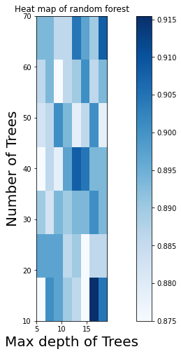

```
------------------------------------------------------
---Optimal combination of parameters of random forests---
Number of decision trees = 10
Depth of decision trees = 17
resulting accuracy: 0.9154411764705882
```

```python
n_trees_list = np.arange(10,80,10)
depth_list = np.arange(5,21,2)

best_n_trees211, best_depth211, best_rf_score = grid_search_random_forest(Xdb_train, ydb_train, 4,
                                        n_trees_list, depth_list, n_features_train, measure='accuracy')
```

According to our heatmap, there is not a really obvious pattern of what pairs of these two hyper-paramters gives good model. Generally speaking, as long as one of the two parameters is large, especially the depth is larger, a good model is more likely to be trained.

Our grid search tells us that the most optimal combination of hyper-parameters are *number of decision trees being 10*, *maximum depth of tree being 17*. This model actually gives a very good *average accuracy of (approx) 0.915*. This means our model correctly classify about 91.5% of the patients in the training dataset.

2.1.2

In this section, I evaluate the performace of our random forest classifier on the test set *diabetes_test* under optimal hyper-parameters selected in section 2.1.1.

The data set *diabetes_test* has been transformed into a python interpretable dataframe and its validity has been checked at the beginning of Task 2. Now I will just extract suitable columns as our feature set and target set for testing.

As usual, standardisation has been applied.

```python
#Remeber we have stacked X and y together, so we have to recover X and y respectively.
Xdb_test = diabetes_test[diabetes_test.columns[:-1]]
ydb_test = diabetes_test[diabetes_test.columns[-1]]

#Standardise
Xdb_test = standardise(Xdb_test)
#Change y into integer
ydb_test = ydb_test.astype(int)

# We need a dictionary indicating whether the column index maps to a
# categorical feature or numerical
# In this example, all features are numerical (categorical=False)
columns_dict = {index: False for index in range(Xdb_train.shape[1])}
```

We firstly train the classifier based on the optimal hyper-parameters found in 2.1.1. Then I use the classifier to predict on our training set and test set respectively, for the evaluation later on.

```python
#Train our model base on optimal parameters
best_n_trees211, best_depth211 = 10, 17
rf_212 = train_rf(best_n_trees211, n_features_train, Xdb_train, ydb_train, columns_dict, best_depth211)

ydb_train_pred212 = predict_rf(rf_212, Xdb_train.to_numpy())
ydb_test_pred212 = predict_rf(rf_212, Xdb_test.to_numpy())
```

As required, measures of *accuracy*, *precision* and *f-score* are used on the predictions of traning and test sets respectively.

```python
#Accuracy
accuracy_train212 = rf_score(ydb_train.to_numpy(), ydb_train_pred212, measure='accuracy')
accuracy_test212 = rf_score(ydb_test.to_numpy(), ydb_test_pred212, measure='accuracy')

#Precision
precision_train212 = rf_score(ydb_train.to_numpy(), ydb_train_pred212, measure='precision')
precision_test212 = rf_score(ydb_test.to_numpy(), ydb_test_pred212, measure='precision')

#Recall
recall_train212 = rf_score(ydb_train.to_numpy(), ydb_train_pred212, measure='tpr')
recall_test212 = rf_score(ydb_test.to_numpy(), ydb_test_pred212, measure='tpr')

#F-score
fscore_train212 = rf_score(ydb_train.to_numpy(), ydb_train_pred212, measure='fscore')
fscore_test212 = rf_score(ydb_test.to_numpy(), ydb_test_pred212, measure='fscore')
```

To viualise the performace, I create a bar chart as follows.

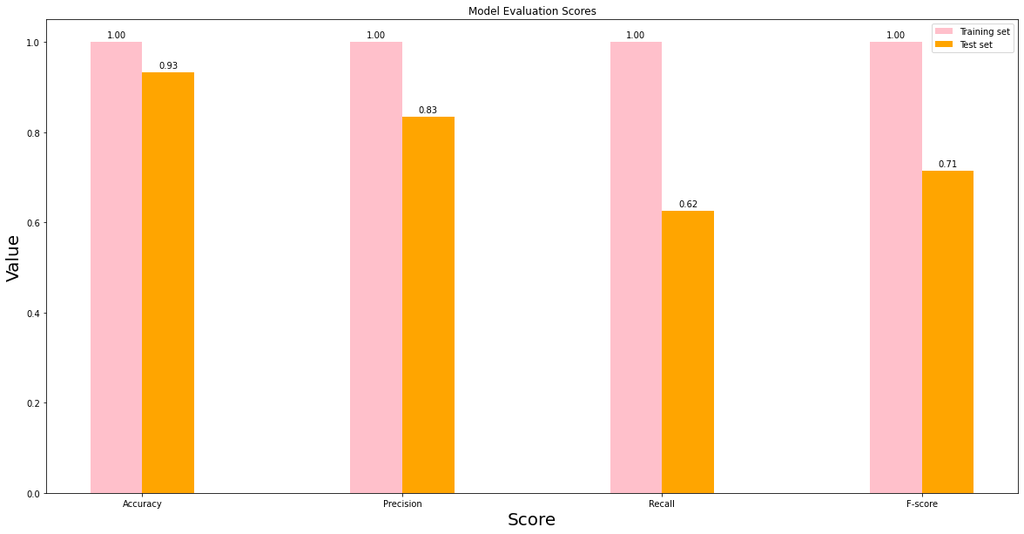

```
---Evaluation of in-sample unweighted fitting---
Accuracy: 1.0
Precision: 1.0
Recall: 1.0
F-score: 1.0
----------------------------------------------------------
---Evaluation of out-of-sample unweighted fitting---
Accuracy: 0.9316239316239316
Precision: 0.8333333333333334
Recalln: 0.625
F-score: 0.7142857142857143
```

```python
# Create a figure and axis object
fig, ax = plt.subplots(figsize=(20,10))

# Set the width of each bar
bar_width = 0.2

# Set the x positions for the bars
x_pos_train = np.array([1, 2, 3, 4])
x_pos_test = x_pos_train + bar_width

# Create the bars
train_bars = ax.bar(x_pos_train, [accuracy_train212, precision_train212, recall_train212, fscore_train212], width=bar_width, color='pink', label='Training set')
test_bars = ax.bar(x_pos_test, [accuracy_test212, precision_test212, recall_test212, fscore_test212], width=bar_width, color='orange', label='Test set')

# Add labels, title, and legend
ax.set_xlabel('Score', size=20)
ax.set_ylabel('Value', size=20)
ax.set_title('Model Evaluation Scores')
ax.set_xticks((x_pos_test + x_pos_train)/2)
ax.set_xticklabels(['Accuracy', 'Precision', 'Recall', 'F-score'])
ax.legend()

# Add labels for each bar
def add_labels(bars):
    for bar in bars:
        height = bar.get_height()
        ax.annotate('{:.2f}'.format(height),
                    xy=(bar.get_x() + bar.get_width() / 2, height),
                    xytext=(0, 3),  # 3 points vertical offset
                    textcoords="offset points",
                    ha='center', va='bottom')

# Add labels to the bars
add_labels(train_bars)
add_labels(test_bars)

# Show the plot
plt.show()

print("---Evaluation of in-sample unweighted fitting---")
print(f"Accuracy: {accuracy_train212}")
print(f"Precision: {precision_train212}")
print(f"Recall: {recall_train212}")
print(f"F-score: {fscore_train212}")
print(f"----------------------------------------------------------")
print("---Evaluation of out-of-sample unweighted fitting---")
print(f"Accuracy: {accuracy_test212}")
print(f"Precision: {precision_test212}")
print(f"Recalln: {recall_test212}")
print(f"F-score: {fscore_test212}")
```

Base on the definition of accuracy, we can tell it measures the proportion of correct outcomes of the model. As in-sample accuracy being 1.0, our classifier is able to classify diabetes and no diabetes accurately. Out-sample accuracy being 0.93 means 93% patients in the test set are correctly classifed.

Precision bascially measures how confident we are when the model predicts positive, in other words, how many of those diabetes cases are indeed correctly classified. In-sample precision being almost 1 means there is no healty patient being diagnosed as diabetic wrongly. The out-of-sample means 83% of the diagonalised patients are indeed diabetic while the rest 17% are healthy.

F-score conatins two pieces of information: how close precison and recall are to 1, and how close precision and recall are. As recall is defined as a proportion of positive values identified by the model, a low out-of-sample recall can mean some positive patients are miss out leading to a high FN. In-sample recall being 1 means zero diabetic patient is missed. Thus out-sample f-score being lower than precision can suggest that our model is having a lower recall. This can be a result of imbalanced data, as if the training set is heavily imbalanced, the model can simply always choose the majority class, leading to the increase of false negative (if the majority class is negative). This will be explored and addressed in the next section.

Last but not least, as all three measures shows that our classifier perform extremely well on its training set, but not in test set, it can suggests that the classifier is overfitting or affected by the distribution of target data.

2.1.3

In this section, we are adding a sample weight to random forest classifier for imbalanced dataset. On an imbalanced datset, the resulting model may be biased towards the majority class, which can lead to poor performance on the minority class. By assigning weights to the samples in the training set, we can balance the contribution of the different classes during training. In this way, we can give more importance to the minority class and avoid having a model that is biased towards the majority class.

I first write a function to demonstrate the imbalance of our training data and find appropriate sample weight for each. The weight is calculated as follows:

$$ \frac{\text{weight}_\text{minority}}{\text{weight}_\text{majority}} = \frac{\text{frequency}_\text{majority}}{\text{frequency}_\text{minority}} $$

In such way, the minority class has a lower frequency, and it will be receive a higher weights. So that all values are equally weighted, reducing the bias of our selection in decision trees.

```python
def compute_class_weights(y, show=False):
    """
    Calculates class weights for imbalanced binary classification tasks.

    :param y: The training labels.

    :return training_weights: An array of weights for each sample in the training set.
    """
    #Count the frequency of each class in the training set
    unique, counts = np.unique(y, return_counts=True)
    if show:
        print('---Counts/Frequency of patient status in training set---')
        for val, count in zip(unique, counts):
            print(f"Counts of {val}: {count}; Frequency of {val}: {count / counts.sum()}")

    #Create a dictionary with the frequency of each class
    class_frequency = dict(zip(unique, counts))
    #Calculate the total number of samples in the training set
    total = sum(class_frequency.values())
    #Calculate the class weights as the inverse of the frequency
    class_weights = {key: total / value for key, value in class_frequency.items()}

    if show:
        print('---Class weights for binary outcome---')
        for key, value in class_weights.items():
            print(f"Weight for class {key}: {1 - 1/value}")

    #Assign a weight to each sample in the training set based on its class
    training_weights = np.zeros(len(y))
    for i, value in enumerate(y):
        training_weights[i] = class_weights[value]
    weights = 1 - 1 / training_weights
    return weights / sum(weights)
```

```python
bootstrap_weights = compute_class_weights(ydb_train, show=True)
```

```
---Counts/Frequency of patient status in training set---
Counts of -1: 229; Frequency of -1: 0.8388278388278388
Counts of 1: 44; Frequency of 1: 0.16117216117216118
---Class weights for binary outcome---
Weight for class -1: 0.16117216117216115
Weight for class 1: 0.8388278388278388
```

Our results demonstrates that in the training dataframe, only 44 patients, out of 273, are diabetic; while 229 patients are being non-diabetic. We conclude that our dataset is heavily imbalanced. Notice that the printed weights are not standardised yet, they are just a taste of what the weights look like. The returned weights have been standardised.

Such rare-class learning problem existing in our training dataset, we want to care more about the retrieval of the positive class, we follow the methodology I presented above, add the training weight based on its frequency in bootstrapping, and repeat the grid search.

Notice I am not adding weights to the *sample_weights* used in majority vote as the question is looking for the effect of weighted bootstrapping.

```
Grid search in progress...
Grid search all finished.
```

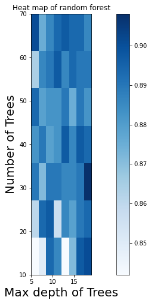

```
------------------------------------------------------
---Optimal combination of parameters of random forests---
Number of decision trees = 30
Depth of decision trees = 19
resulting accuracy: 0.9080882352941176
```

```python
n_trees_list = np.arange(10,80,10)
depth_list = np.arange(5,21,2)
best_n_trees213, best_depth213, best_rf_score = grid_search_random_forest(Xdb_train, ydb_train, 4,
                                        n_trees_list, depth_list, n_features_train,
                                        bootstrap_weight=compute_class_weights, measure='accuracy')
```

As we can see, the optimal hyper-parameters have been changed to **30 decision trees** and **19 depth of each decision tree**. This combination gives use average accuracy besing 0.908.

Next we train the full dataset using these hyper-parameters, and use it to predict on both training set and test set.

```python
#Train our model base on optimal parameters
best_n_trees213, best_depth213 = 30, 19
rf_weighted = train_rf(best_n_trees213, n_features_train, Xdb_train, ydb_train, columns_dict, best_depth213, bootstrap_weight=compute_class_weights)

ydb_train_pred213 = predict_rf(rf_weighted, Xdb_train.to_numpy())
ydb_test_pred213 = predict_rf(rf_weighted, Xdb_test.to_numpy())
```

Same, accuracy, precision and f-score are used.

```python
#Accuracy
accuracy_train213 = rf_score(ydb_train.to_numpy(), ydb_train_pred213, measure='accuracy')
accuracy_test213 = rf_score(ydb_test.to_numpy(), ydb_test_pred213, measure='accuracy')

#Precision
precision_train213 = rf_score(ydb_train.to_numpy(), ydb_train_pred213, measure='precision')
precision_test213 = rf_score(ydb_test.to_numpy(), ydb_test_pred213, measure='precision')

#Recall
recall_train213 = rf_score(ydb_train.to_numpy(), ydb_train_pred213, measure='tpr')
recall_test213 = rf_score(ydb_test.to_numpy(), ydb_test_pred213, measure='tpr')

#F-score
fscore_train213 = rf_score(ydb_train.to_numpy(), ydb_train_pred213, measure='fscore')
fscore_test213 = rf_score(ydb_test.to_numpy(), ydb_test_pred213, measure='fscore')
```

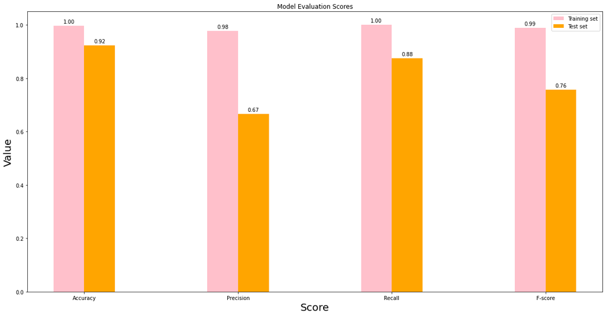

```
---Evaluation of in-sample weighted fitting---
Accuracy: 0.9963369963369964
Precision: 0.9777777777777777
Recall: 1.0
F-score: 0.9887640449438202
----------------------------------------------------------
---Evaluation of out-of-sample weighted fitting---
Accuracy: 0.9230769230769231
Precision: 0.6666666666666666
Recalln: 0.875
F-score: 0.7567567567567567
```

```python
# Visualisation
# Create a figure and axis object
fig, ax = plt.subplots(figsize=(20,10))

# Set the width of each bar
bar_width = 0.2

# Set the x positions for the bars
x_pos_train = np.array([1, 2, 3, 4])
x_pos_test = x_pos_train + bar_width

# Create the bars
train_bars = ax.bar(x_pos_train, [accuracy_train213, precision_train213, recall_train213, fscore_train213], width=bar_width, color='pink', label='Training set')
test_bars = ax.bar(x_pos_test, [accuracy_test213, precision_test213, recall_test213, fscore_test213], width=bar_width, color='orange', label='Test set')

# Add labels, title, and legend
ax.set_xlabel('Score', size=20)
ax.set_ylabel('Value', size=20)
ax.set_title('Model Evaluation Scores')
ax.set_xticks((x_pos_test + x_pos_train)/2)
ax.set_xticklabels(['Accuracy', 'Precision', 'Recall', 'F-score'])
ax.legend()

# Add labels for each bar
def add_labels(bars):
    for bar in bars:
        height = bar.get_height()
        ax.annotate('{:.2f}'.format(height),
                    xy=(bar.get_x() + bar.get_width() / 2, height),
                    xytext=(0, 3),  # 3 points vertical offset
                    textcoords="offset points",
                    ha='center', va='bottom')

# Add labels to the bars
add_labels(train_bars)
add_labels(test_bars)

# Show the plot
plt.show()

print("---Evaluation of in-sample weighted fitting---")
print(f"Accuracy: {accuracy_train213}")
print(f"Precision: {precision_train213}")
print(f"Recall: {recall_train213}")
print(f"F-score: {fscore_train213}")
print(f"----------------------------------------------------------")
print("---Evaluation of out-of-sample weighted fitting---")
print(f"Accuracy: {accuracy_test213}")
print(f"Precision: {precision_test213}")
print(f"Recalln: {recall_test213}")
print(f"F-score: {fscore_test213}")
```

This is the bar chart of the performace of our weighted classifier on training set and test respectively. Before I interpret the results, let me concatenate the unweighted and weighted bootstrapping together to make direct comparison.

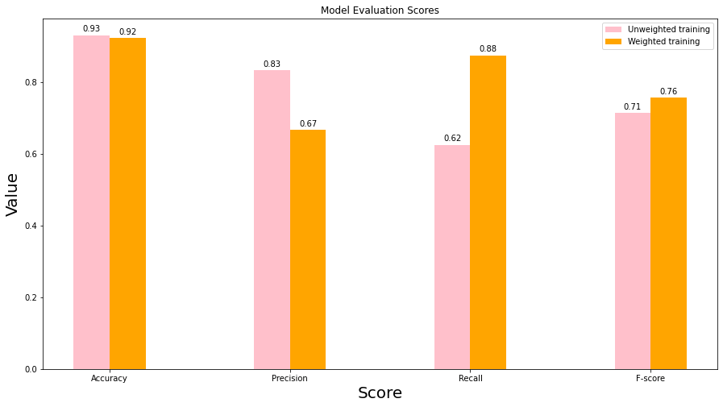

```
---Numerical comparison of unweighted/weighted fitting on test set---
---Accuracy---
Unweighted: 0.9316239316239316
Weighted: 0.9230769230769231
---Precision---
Unweighted: 0.8333333333333334
Weighted: 0.6666666666666666
---Recall---
Unweighted: 0.625
Weighted: 0.875
---F-score---
Unweighted: 0.7142857142857143
Weighted: 0.7567567567567567
```

```python
# Create a figure and axis object
fig, ax = plt.subplots(figsize=(15,8))

# Set the width of each bar
bar_width = 0.2

# Set the x positions for the bars
x_pos_train = np.array([1, 2, 3, 4])
x_pos_test = x_pos_train + bar_width

# Create the bars
train_bars = ax.bar(x_pos_train, [accuracy_test212, precision_test212, recall_test212, fscore_test212], width=bar_width, color='pink', label='Unweighted training')
test_bars = ax.bar(x_pos_test, [accuracy_test213, precision_test213, recall_test213, fscore_test213], width=bar_width, color='orange', label='Weighted training')

# Add labels, title, and legend
ax.set_xlabel('Score', size=20)
ax.set_ylabel('Value', size=20)
ax.set_title('Model Evaluation Scores')
ax.set_xticks((x_pos_test + x_pos_train)/2)
ax.set_xticklabels(['Accuracy', 'Precision', 'Recall', 'F-score'])
ax.legend()

# Add labels for each bar
def add_labels(bars):
    for bar in bars:
        height = bar.get_height()
        ax.annotate('{:.2f}'.format(height),
                    xy=(bar.get_x() + bar.get_width() / 2, height),
                    xytext=(0, 3),  # 3 points vertical offset
                    textcoords="offset points",
                    ha='center', va='bottom')

add_labels(train_bars)
add_labels(test_bars)

# Show the plot
plt.show()

print("---Numerical comparison of unweighted/weighted fitting on test set---")
print("---Accuracy---")
print(f"Unweighted: {accuracy_test212}")
print(f"Weighted: {accuracy_test213}")
print("---Precision---")
print(f"Unweighted: {precision_test212}")
print(f"Weighted: {precision_test213}")
print("---Recall---")
print(f"Unweighted: {recall_test212}")
print(f"Weighted: {recall_test213}")
print("---F-score---")
print(f"Unweighted: {fscore_test212}")
print(f"Weighted: {fscore_test213}")
```

The *accuracy* which is defined as $$ \frac{TP+TN}{N_\text{validation}} $$ descrease by 0.008 after we bootstrapped according to weights. However, the accuracy of unweighted classifier can be very misleading. As *diabetes_sample* is heavily imbalanced with 229 negative patients (-1) and 44 positive patients (+1), the distribution is severly skewed. In such case, the unweighted classifier will always have loads of '-1' in its traning data because we were bootstrapping uniformly, it of course always predicts the dummy majority class "-1". It gives us a high true negative rate. But this result is trivial because we focus more on those diabetic patients, and such high accuracy resulting from TN is trivial, useless and misleading in the imbalanced dataset. After we add weights to bootstrapping, now both '-1' and '1' are equally likely to be chosen as samples of training data, as such, less '-1' will be predicted, and we could expect our TN to decreases. However it also predicts more positive patients (not necessary correctly), which could lead to a higher true positive rate. These two combines together can give us a slightly lower accuracy compared to the unweighted one. Yet it doesn't mean the unweighted one is better as it is misleading.

There is a big drop in *precision* by almost 0.2, just remind ourself that precision is defined as $$ \frac{TP}{TP+FP} = \frac{TP}{P} $$ We also plot the change in *recall* which is defined as $$ \frac{TP}{TP+FN} $$ where there is an large increase in it by 0.25. As I said, before adding the bootstrapping weight, samples will be uniformly chosen from our severly skewed dataset, which means the majority values in our sample will be negative. Thus, the classifier is highly likely to assigns a negative majority to our sample, which is more likely to be correct (TN), but a small risk of FN. In other word, the classifier will only predict a positive majority when it is very confident about our sample, even at the expense that it does not predict any positive class. Let us assume at least one positive class has been assigned, otherwise preicison will be undefined. Unweighted classifier could lead to a very high precision as FP will be very low. But this is not what we want, as we do not want to miss out any diabetic patients. After selecting traning samples based on weights, we could expect (-1) and (1) will be more evenly distributed in our sampled training set, and our new classifier will start to tend to predict positive class. This could lead to a decrease in FN, but at a risk of higher FP. The risk can be accepted because we genuinely does not want to miss out any diabetic patients, even at expense of pointing some non-diabetic patient as potentially diabetic.

Last but not least, the F-score, taking into account of both precision and recall as

$$ 2 \cdot \frac{\text{precision} \cdot \text{recall}}{\text{precision} + \text{recall}} $$

It could balance our results in precision and recall by estimating how close they are. This metric is very important in imbalanced dataset. As we can see, there is 0.05 increase in f-score of weighted classifier. This suggests than, although precision of weighted classifier is lower, a higher recall balances out the performace, suggesting the weighted one is better in classification of our data set. This is also inline with out duty: we aim at minimising the risk of missed diagonases.

As lecture notes suggested, we should focus more on measures excluding True Negatives, which means accuracy is misleading, we can conclude from our f-score that our weights are added successfully and giving us a better random forest classifier.

As the final part of random forest classification, let us explore the ROC and Precision-Recall curve. The following is the implementation to plot those two curves.

Notice that I have updated the `predict_rf` function perform by adding an argument *threshold*, such that only the frequency of non-diabetic patients in one batch is larger than our threshold, this batch will be classifed as non-diabetes. We will scan through a range of threshold to see the trade-off between TPR and FPR, as well as precision and recall.

Notice if we encounter the case that zero positive class is predicted, we define the precision as zero rather than NaN to make our plot valid and continuous, but it doesn't affect the area under the curve.

```python
def roc_prerecall_curve(rf, X_test, y_test, thresholds):
    """
    Calculate ROC and Precision-Recall curves for a given random forest classifier.


    :param rf: the random forest classifier to evaluate
    :param X_test: the test set features
    :param y_test: the test set labels
    :param thresholds (numpy array): the array of thresholds to use for classification

    Returns:
    auc_roc (float): the area under the ROC curve
    auc_precision (float): the area under the precision-recall curve
    tpr_l (list): the true positive rate for each threshold
    fpr_l (list): the false positive rate for each threshold
    precision_l (list): the precision for each threshold
    thresholds (numpy array): the array of thresholds used for classification
    """
    #Initialize lists for true positive rate, false positive rate, and precision
    tpr_l, fpr_l = [], []
    precision_l = []

    for threshold in thresholds:
        #Apply thresholding to obtain binary classification
        y_pred = predict_rf(rf, X_test, threshold)

        #Calculate the confusion matrix
        cm = confusion_matrix(y_test, y_pred)
        tn, fp, fn, tp = cm.ravel()

        # true positive rate
        tpr =  tp / (tp + fn)
        # false positive rate
        fpr =  fp / (tn + fp)
        # precision
        if tp == 0 & tp == 0:
            precision = 0
        else:
            precision = tp / (tp + fp)

        tpr_l.append(tpr)
        fpr_l.append(fpr)
        precision_l.append(precision)

    #Compute the area under the ROC curve and the precision-recall curve using the trapezoidal rule
    auc_roc = np.trapz(tpr_l, fpr_l)
    auc_precision = np.trapz(precision_l, tpr_l)

    return auc_roc, auc_precision, tpr_l, fpr_l, precision_l, thresholds
```

We will now test our threshold on applying the classifiers to the test set *diabetes_test* using weighted and unweighted bootstrap respectively.

Here a list of threshold from 0.1 to 1 with step size 0.01 has been used. If we include threshold = 0, by my aggregate function, it will always predict negative class, which is not imformative.

```python
#Weighted bootstrap
auc_roc, auc_precision, tpr, fpr, precision, th_1 = roc_prerecall_curve(rf_weighted, Xdb_test.to_numpy(), ydb_test.to_numpy(), np.arange(0.1,1.1,0.01))

#Unweighted bootstrap
auc_roc_2, auc_precision_2, tpr_2, fpr_2, precision_2, th_2 = roc_prerecall_curve(rf_212, Xdb_test.to_numpy(), ydb_test.to_numpy(), np.arange(0.1,1.1,0.01))
```

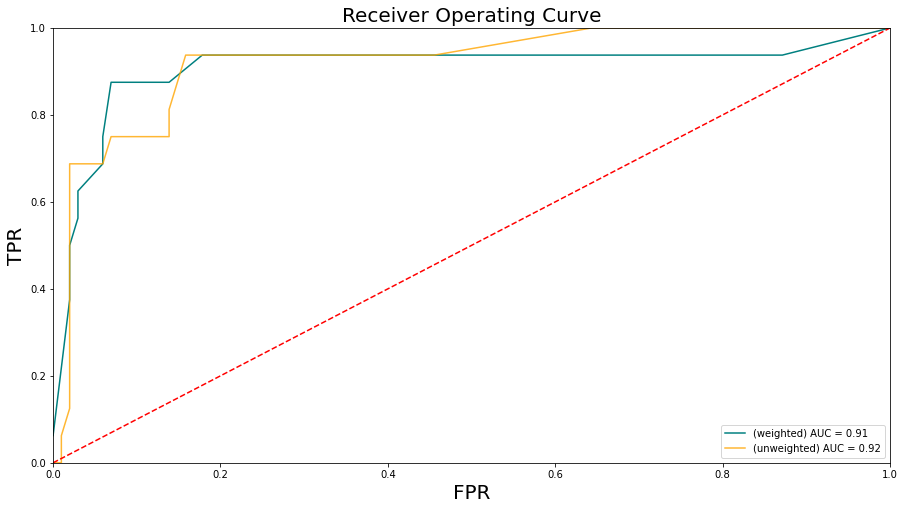

```python
#Plot of ROC
plt.figure(figsize=(15,8))
plt.title(f"Receiver Operating Curve", size=20)
plt.plot(fpr, tpr, 'teal', label = f'(weighted) AUC = {auc_roc:0.2f}')
plt.plot(fpr_2, tpr_2, 'orange', alpha=0.8, label = f'(unweighted) AUC = {auc_roc_2:0.2f}')
plt.legend(loc = 'lower right')
plt.plot([0, 1], [0, 1],'r--')
plt.xlim([0, 1])
plt.ylim([0, 1])
plt.ylabel('TPR', size=20)
plt.xlabel('FPR', size=20)
plt.show()
```

Let us analyse the receiver operation characteristic curve. The ROC curve is generated by plotting the true positive rate (TPR) against the false positive rate (FPR) for different classification threshold.

$$ \text{TPR}=\frac{TP}{TP+FN} \quad \text{and} \quad \text{FPR}=\frac{FP}{FP+TN} $$

We can visualise the trade-off between TPR and FPR through this plot. For example, if we set the threshold incredibly close to 1, which means in my function, only when the frequency of 'No Diabetes' is 1, our model will classify it as 'No Diabetes'. Under such scenario, our classifier always predicts the positive class. Good news is it will correctly identify all positive examples(TP=1) without giving any nagetives (FN=0), which gives us TPR=1, but it will also classify all the negative ones as positive wrongly (FP=1, TN=0 means FPR=1). Vice versa. In general, as the threshold increases, it means more positive classes will be identified, leading to the increase in TPR and FPR at the same time, so we can see our curve starts from bottom left, approaching top right.

The numerical evaluation of ROC curve is by the AUC, area under the curve. It summarises the overall performace of the classifer. It ranges from 0.5 to 1.0, where a value of 0.5 means the classifer performs no better than random guessing, and a value of 1.0 means the classifer has perfect performace. AUC can be interpreted as the probability that a randomly choosen positive example (Diabetic patient) is ranked higher than a randomly choosen negative example by the classifier. In other words, it measures how well our model can separate the "Diabetes" and "No Diabetes". A higher AUC indicates better performace.

Also a steeper curve indicates that the classifer has a high TPR even at low FPR, which suggests good performance.

By comparing the AUC score, it appears that these two classifiers are performing similarily, the uniweghted one even slighly out-performed the weighted one. But this is misleading in our severly imbalanced dataset.

Consider the unweighted case, while we increase the threshold, (-1) is getting harder to get predicted. This decreases FN (as there won't be as many as negatives as usual), but could also increases FP (as more positive is appearing). Both will lead to higher increase in TPR and FPR, resulting a higher AUC score. However, higher TPR is at expense of low TP: barely any real diabetic patients is pointed out. This suggests that although its AUC is high, the reasons behind him are not what we want, or even what we are trying to avoid.

Next turn to the ROC AUC score of weighted case. Weighted bootstrap sampling is designed to give more importance to samples that are more difficult to classify correctly, which is the minority class ('Diabetes') in *diabetes_sample*. As the FN in TPR decreases (less bias to negative class) as threshold does, TP can also increases by weighting. This makes the increase in TPR less obvious. Likewise, as FP increases as threshold does, but TN is also high in our case, as there is no bias to negative majority class. These are good reasons behind a high AUC score.

In conclusion, although weighted and unweighted cases have similar AUC score, weighted one has our desired motivation behind it, yet unweighted one is having things we want to avoid. In such case, AUC score of ROC is not very informative and is a bit misleading.

As a compensate, we now use another way to evaluate the perforamce -- Precision-Recall curve.

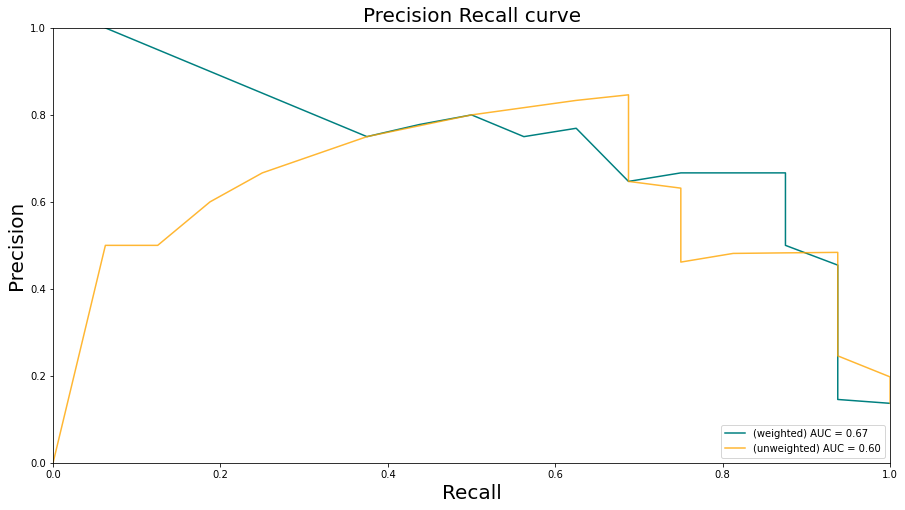

```python
#PRecision-Recall curve
plt.figure(figsize=(15,8))
plt.title(f"Precision Recall curve", size=20)
plt.plot(tpr, precision, 'teal', label = f'(weighted) AUC = {auc_precision:0.2f}')
plt.plot(tpr_2, precision_2, 'orange', alpha=0.8, label = f'(unweighted) AUC = {auc_precision_2:0.2f}')
plt.legend(loc = 'lower right')
plt.xlim([0, 1])
plt.ylim([0, 1])
plt.ylabel('Precision', size=20)
plt.xlabel('Recall', size=20)
plt.show()
```

Precision-recall curve is more useful in our case than ROC because our training set is heavily imbalanced. The negative class dominating the positive class in terms of sample size makes ROC difficult to evaluate the performace of a classifier based on the overall accuracy or ROC where True Negative is included. Instead, the precision-recall curve plots precision against recall, focusing more on the effective diagonise of minority class 'Diabetes'. It measures how well the classifier is able to detect positive class (recall) with avoiding false positive (precision）.

$$ \text{precision} = \frac{TP}{TP+FP} \quad \text{and} \quad \text{recall} = \frac{TP}{TP+FN} $$

Trade-off can also exists as changing threshold is applied. For example, if I set the threshold extremely close to 0, which means almost every drawn sample will be loaded with '-1', of course it will get classified as 'No diabetes'. Only people with a very high probability of having diabetes are classified as positive. In such case, (assuming our classifer at least classified one positive case), FP will be extremely low because the classifier is very confident about its positive predictors, the precision will be extremely close to 1. However, recall will be low because we simply classify a large proportion of patients as negative which results a high FN rate. Vice versa. Our plot gives the shape we would expect -- at thresholds with low recall, the precision is correspondingly high.

A higher AUC indicates our classifer has overall high recall and high precision in together. We can see the AUC of weight bootstrap is 0.67, much higher than 0.60 of unweighted one. This indicates that weighted bootstrap helps to diagnose as much true positive as possible, meanwhile retain a lower false negative rate. This is desirable in our case because we successfully discover most diabetic patients, minimise the hidden diabetic patients we missed out.

In conclusion, in a very skewed dataset as *diabetes_samples*, AUC of Precision-Recall Curve is more informative, and indeed weighted bootstrapping gives us a better classifier.

#### 2.2 Support Vector Machine (SVM) (30 marks)

2.2.1

In this section, I will train a soft-margin linear SVM classifier by minimising the loss function $$ L = \frac{1}{2} \|\boldsymbol w\|^2 + \lambda \sum_{i=1}^N max\{0, 1-y^{(i)}(\boldsymbol x^{(i)} \cdot \boldsymbol{w} + b)\} $$ to find an optimal hyper-plane $\mathbb{H} := \{ \boldsymbol x: \boldsymbol x \cdot \boldsymbol w + b=0\}$ where parameter $\boldsymbol w \in \mathbb{R}^n$ and normal direction $b \in \mathbb{R}$.

Soft-margin linear SVM is used when the dataset is not possible for perfect hard-margin separation. In other words, we can not find a hyper-plane that separates binary outcomes perfectly. Instead, we allow some points to fall onto the wrong side of the plane. We do this by introducing the penalty term, and the hyper-parameter $\lambda$ serves as a degree of importance that is given to misclassifications. When $\lambda$ tends to 0 (without being 0) the more the miss-classifications are allowed.

As usual, we first set up feature set and target set. One thing to notice is that we also set up an argument matrix for freature set to include the normal dirction $b$. But unlike in section 1, we here add the column vector of ones on the right:

$$ X' = (X|1) $$

Correspondingly $b$ is added to $\mathbf{w}$ as last entry.

```python
#Xdb_train has been standardisd in section 2.1
#Cast column 1 to make it augmented matrix
N, D = Xdb_train.shape
Xdb_train_aug = np.hstack((Xdb_train, np.ones((N,1))))

#Change y to numpy
ydb_train = ydb_train.to_numpy()

#Apply everything to testset
#Xdb_test_std = standardise(Xdb_test)
M, D = Xdb_test.shape
Xdb_test_aug = np.hstack((Xdb_test, np.ones((M,1))))

ydb_test = ydb_test.to_numpy()
```

We use the stochastic gradient descent to minimise our loss function, and following codes are quoted from the exercise notebook.

Derivative of 2-norm squared is illustrated in section 1, here I will just write down the results:

$$ \frac{\partial}{\partial \omega} L= \begin{cases}w & \text { if } 1-y^{(i)}\left(x^{(i)} \cdot w+b\right) \leqslant 0 \\ & \\ w - \lambda \sum_{i=1}^N y^{(i)} x^{(i)} & \text { otherwise }\end{cases} $$

```python
def compute_cost(w, X, y, regul_strength=1e5):
    """
    Calculate the cost of the loss function of soft-margin linear SVM.

    :param w: parameter of hyper-plane
    :param X: feature set (include normal direction b)
    :param y: target set (Binary classification in our case)
    :param regul_strength: degree of importance of misclassification

    :return cost: cost of the loss function

    """
    n = X.shape[0]
    distances = 1 - y * (X @ w)
    distances[distances < 0] = 0  # equivalent to max(0, distance)
    hinge = regul_strength * distances.mean()

    # calculate cost
    return 0.5 * np.dot(w, w) + hinge -0.5*w[-1]**2


def calculate_cost_gradient(w, X_batch, y_batch, regul_strength=1e6):
    """
    Calculate the gradient of the cost function of soft-margin linear SVM for a batch of examples.

    :param w: parameter of hyper-plane
    :param X_batch: a batch of feature vectors (include normal direction b)
    :param y_batch: a batch of target values (Binary classification in our case)
    :param regul_strength: degree of importance of misclassification

    :return dw: gradient of the cost function with respect to w
    """
    # if only one example is passed
    if type(y_batch) == np.float64 or type(y_batch) == np.int64:
        y_batch = np.asarray([y_batch])
        X_batch = np.asarray([X_batch])  # gives multidimensional array

    distance = 1 - (y_batch * (X_batch @ w))
    dw = np.zeros(len(w))

    we = w.copy() # So as not to overwrite w
    we[-1] = 0 # So as not to have b in its derivative when adding the weights in di

    for ind, d in enumerate(distance):
        if max(0, d)==0:
            di = we # derivative of first term
        else:
            di = we - (regul_strength * y_batch[ind] * X_batch[ind])
        dw += di

    return dw/len(y_batch)  # average

def sgd(X, y, max_iterations=2000, stop_criterion=0.01, learning_rate=1e-5, regul_strength=1e6, print_outcome=False):
    """
    Perform stochastic gradient descent to train a soft-margin linear SVM.

    :param X: feature set (include normal direction b)
    :param y: target set (Binary classification in our case)
    :param max_iterations: maximum number of iterations to perform
    :param stop_criterion: minimum relative change in cost for convergence
    :param learning_rate: the step size of each iteration
    :param regul_strength: degree of importance of misclassification
    :param print_outcome: whether to print cost and iteration during training

    :return weights: final weights of the SVM model
    """
    # initialise zero weights
    weights = np.zeros(X.shape[1])
    nth = 0
    # initialise starting cost as infinity
    prev_cost = np.inf

    # stochastic gradient descent
    indices = np.arange(len(y))

    for iteration in range(1, max_iterations):
        # shuffle to prevent repeating update cycles
        np.random.shuffle(indices)
        X, y = X[indices], y[indices]

        for xi, yi in zip(X, y):
            descent = calculate_cost_gradient(weights, xi, yi, regul_strength)
            weights = weights - (learning_rate * descent)

        # convergence check on 2^n'th iteration
        if iteration==2**nth or iteration==max_iterations-1:
            # compute cost
            cost = compute_cost(weights, X, y, regul_strength)
            if print_outcome:
                print("Iteration is: {}, Cost is: {}".format(iteration, cost))
            # stop criterion
            if abs(prev_cost - cost) < stop_criterion * prev_cost:
                return weights

            prev_cost = cost
            nth += 1

    return weights
```

We still use accuracy as a measure of performace, so I will make use of functions I defined in section 2.1.

Here is how I predict on test set, given found $\boldsymbol w$ and $b$, calculate $$\boldsymbol X \cdot \boldsymbol{w} + b = 0$$ Points above the plane will be classified as positive (diabetes); points below it will be classified as negative (No Diabetes).

```python
def svm_score(w, X_test, y_test, measure):
    """
    Evaluate the performance of a support vector machine (SVM) model on a test set.

    :param w: A numpy array containing the weights of the SVM model.
    :param X_test: A numpy array of shape (n_samples, n_features) containing the test set features.
    :param y_test: A numpy array of shape (n_samples,) containing the test set labels.
    :param measure: A string indicating the evaluation metric to be used. Possible values are 'accuracy', 'precision', 'recall', 'f1', 'auc'.

    :return score: The value of the evaluation metric for the given SVM model on the test set.
    """
    y_pred = np.sign(X_test @ w)
    return rf_score(y_test, y_pred, measure)
```

The following functions are used to perform a 4-fold cross validation for each hyper-parameter $\lambda$ in a grid search.

```python
def svm_cross_validation_evaluate(X_train1, y_train1, num_folds, regul_strength, measure, max_iteration=5000, stop_criterion=1e-6, learning_rate=1e-5):
    """
    Perform cross-validation on the training set to tune the hyper-parameters and evaluate the performance of the
    model.

    :param X_train1: feature set of the training set
    :param y_train1: target set of the training set
    :param num_folds: number of folds to be used for cross-validation
    :param regul_strength: degree of importance of misclassification
    :param measure: evaluation metric to be used for scoring
    :param max_iteration: maximum number of iterations for stochastic gradient descent algorithm
    :param stop_criterion: stopping criterion for early termination of training
    :param learning_rate: learning rate for the stochastic gradient descent algorithm

    :return: mean of the training scores, mean of the validation scores
    """

    def cross_val_split(N, num_folds):
        fold_size = N // num_folds
        #np.random.seed(2)
        index_perm = np.random.permutation(np.arange(N))
        folds = []
        for k in range(num_folds):
            folds.append(index_perm[k*fold_size:(k+1)*fold_size])
        return folds

    folds = cross_val_split(X_train1.shape[0], num_folds)

    train_scores = []
    val_scores = []

    for i in range(len(folds)):

        val_indices = folds[i]
        # define the training set
        train_indices = list(set(range(X_train1.shape[0])) - set(val_indices))

        X_train = X_train1[train_indices, :]
        y_train = y_train1[train_indices]

        # define the validation set
        X_val = X_train1[val_indices, :]
        y_val = y_train1[val_indices]

        # insert 1 in every row for intercept b
        X_train = np.hstack((X_train, np.ones((len(X_train),1)) ))
        X_val = np.hstack((X_val, np.ones((len(X_val),1)) ))

        # train the model
        w = sgd(X_train, y_train, max_iterations=max_iteration, stop_criterion=stop_criterion,
                learning_rate=learning_rate, regul_strength=regul_strength)

        # evaluate
        train_score = svm_score(w, X_train, y_train, measure)
        val_score = svm_score(w, X_val, y_val, measure)

        train_scores.append(train_score)
        val_scores.append(val_score)

    train_scores_mean = np.mean(np.array(train_scores))
    val_scores_mean = np.mean(np.array(val_scores))

    return train_scores_mean, val_scores_mean

def svm_choose_best_lambda(X_train, y_train, folds, lambda_range, measure, max_iteration=2000, stop_criterion=0.01, learning_rate=1e-3):
    """
    Choose the best regularization parameter (lambda) for a soft-margin SVM using cross-validation.

    Args:
        X_train (ndarray): Training data input features with shape (n_samples, n_features).
        y_train (ndarray): Training data target variable with shape (n_samples,).
        folds (int): Number of folds for cross-validation.
        lambda_range (list): List of regularization parameters to try.
        measure (str): The evaluation metric to use. 'accuracy', 'f1_score', 'precision', or 'recall'.
        max_iteration (int): Maximum number of iterations for the stochastic gradient descent optimization algorithm.
        stop_criterion (float): The stopping criterion for the stochastic gradient descent optimization algorithm.
        learning_rate (float): The learning rate for the stochastic gradient descent optimization algorithm.

    Returns:
        float: The optimal regularization parameter (lambda) that maximizes the validation set accuracy.
    """
    lambda_train_scores = np.zeros(len(lambda_range))
    lambda_val_scores = np.zeros(len(lambda_range))

    #Loop over each lambda
    for i, lambda_ in enumerate(lambda_range):
        #print(lambda_)
        lambda_train_scores[i], lambda_val_scores[i] = svm_cross_validation_evaluate(X_train, y_train, folds, lambda_,
                                        measure, max_iteration, stop_criterion, learning_rate)
    best_lambda_idx = np.argmax(lambda_val_scores)

    plt.figure(figsize=(15,8))
    plt.plot(lambda_range, lambda_train_scores, color='teal', marker='o', linestyle='-', alpha=0.5, label='Training set accuracy')
    plt.plot(lambda_range, lambda_val_scores, color='orange', marker='o', linestyle='-', label='Validation set accuracy')
    plt.plot(lambda_range[best_lambda_idx], np.max(lambda_val_scores), marker='*', color='red', markersize=15)
    plt.xlabel('Lambda', size=20)
    plt.ylabel('Average Accuracy', size=20)
    plt.title(r"Grid search of $\lambda$ of soft-margin SVM", size=20)
    plt.legend()
    plt.grid()
    plt.show()

    print("-------------------------------------")
    print(f"Optimal hardness hyper-parameter lambda: {lambda_range[best_lambda_idx]}")
    print(f"Resulting maximum accuracy: {np.max(lambda_val_scores)}")
    return lambda_range[best_lambda_idx]
```

Next I scan through $\lambda$ from 1 to 50 to find the one giving highest average accuracy in validation sets.

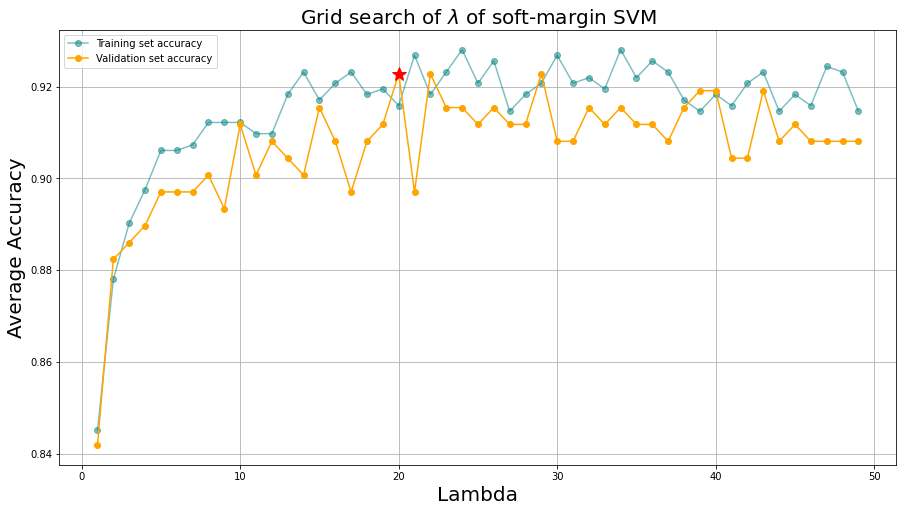

```
-------------------------------------
Optimal hardness hyper-parameter lambda: 20
Resulting maximum accuracy: 0.9227941176470589
```

```python
lambda_range = np.arange(1,50)
best_lambda221 = svm_choose_best_lambda(Xdb_train.to_numpy(), ydb_train, 4, lambda_range, 'accuracy')
```

Our reported optimal hardness $\lambda$ is 20, and the average accuracy is approx 0.923.

Optimal SVM wants to increase the distance of decision boundary to classes (or support vectors), and maximize the number of points that are correctly classified in the training set.

For low hardness penalty, $\lambda$ is small, the penalty for misclassified points is low so a decision boundary with a large margin is chosen at the expense of a greater number of misclassifications. The SVM will not be sensitive to new data points added in. The good thing is the SVM will perform equally good and stable on training set and test set, however, large amount of misclassification could result in a low accuracy. This can be comfirmed by first section of the plot: two lines are quite close to each other, but accuracy is not satisfactory.

For high hardness, $\lambda$ is large, SVM tries to minimise the number of misclassified examples which results in a decision boundary with a smaller margin. This could give a good classification in the training set, as the accuracy of training set is increasing in the plot as $\lambda$ increases. However, due to the narrow margin in two classes, it is very sensitive to noise and to small changes in the independent variables (new data coming in). This is shown by the gradual decreasing accuracy on validation set for $\lambda > 20$.

2.2.2

To investigate the cosine of angle between to planes, we first write down the plane equations for each:

$$ \boldsymbol x \cdot w_1 + d_1 = 0 \quad \text{and} \quad \boldsymbol x \cdot w_2 + d_2 = 0 $$

The angle $\theta$ between the planes is defined as:

$$ cos(\theta) = |\frac{w_1 \cdot w_2}{|w_1||w_2|}| $$

```python
def train_svm_hyperplanes(X, y, lambdas):
    """
    Trains a Support Vector Machine (SVM) for different values of the regularization strength parameter and computes the cosine similarity
    between the resulting hyperplanes.

    :param X: feature set of the training data
    :param y: target set of the training data
    :param lambdas: list of regularization strengths to be used for training

    :return: a matrix of cosine similarities between the hyperplanes for different regularization strengths
    """
    n_lambdas = len(lambdas)
    cos_sims = np.zeros((n_lambdas, n_lambdas))

    for i, lambdai in enumerate(lambdas):
        wi = sgd(X, y, regul_strength=lambdai)
        wi = wi[:-1]

        # Compute cosine similarity between hyperplanes with the same lambda value
        cos_sims[i, i] = np.dot(wi, wi) / (np.linalg.norm(wi) * np.linalg.norm(wi))

        for j, lambdaj in enumerate(lambdas):
            if i < j:
                wj = sgd(X, y, regul_strength=lambdaj)
                wj = wj[:-1]
                cos_sim = np.dot(wi, wj) / (np.linalg.norm(wi) * np.linalg.norm(wj))
                cos_sims[i, j] = cos_sim
                cos_sims[j, i] = cos_sim

    return cos_sims

lambda_range = np.arange(1,50)
cos_sims = train_svm_hyperplanes(Xdb_train_aug, ydb_train, lambda_range)
```

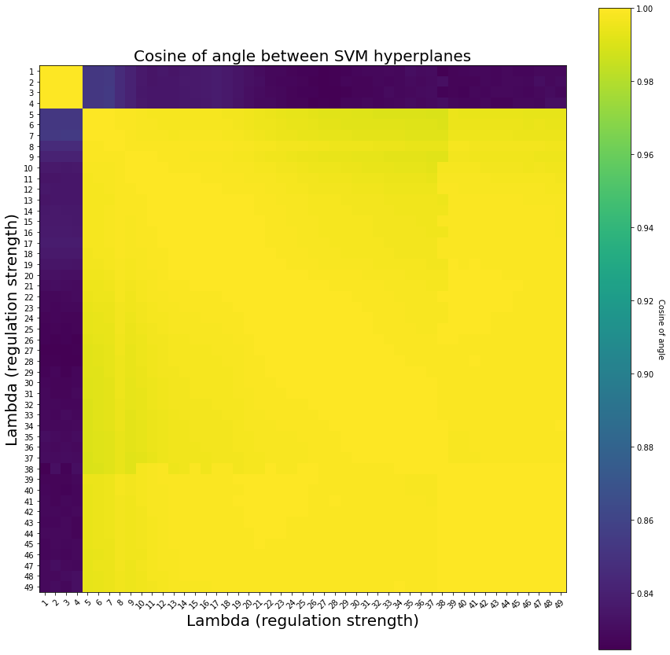

```python
fig, ax = plt.subplots(figsize=(15,15))
im = ax.imshow(cos_sims, cmap='viridis')

# Add colorbar
cbar = ax.figure.colorbar(im, ax=ax)
cbar.ax.set_ylabel('Cosine of angle', rotation=-90, va="bottom")

# Add axis labels and title
ax.set_xticks(np.arange(len(lambda_range)))
ax.set_yticks(np.arange(len(lambda_range)))
ax.set_xticklabels(lambda_range)
ax.set_yticklabels(lambda_range)
ax.set_xlabel('Lambda (regulation strength)', size=20)
ax.set_ylabel('Lambda (regulation strength)', size=20)
ax.set_title('Cosine of angle between SVM hyperplanes', size=20)

# Rotate the tick labels and set their alignment
plt.setp(ax.get_xticklabels(), rotation=45, ha="right", rotation_mode="anchor")

plt.show()
```

The heatmap represents the cosine of the angle between two hyperplanes found using different regularization strengths $\lambda$. The angle between two hyperplanes is the angle between their normal vectors. The cosine of this angle ranges between -1 and 1, where -1 indicates that the two hyperplanes are parallel, 0 indicates that the two hyperplanes are perpendicular, and 1 indicates that the two hyperplanes are in the same direction. In general, a higher (absolute) cosine of the angle between two hyperplanes indicates that the two hyperplanes are more similar with each other, while a lower cosine of the angle between two hyperplanes indicates that the two hyperplanes are more dissimilar to each other.

First of all, all the diagonal blocks have cosine equals to 1, this is trivial as the angle between two parallel planes is of course zero.

From the color bar, we can see the largest difference in angle (equivalent to smallest cosine value) in our plot happens when one $\lambda$ is small, say from 1 to 5, and the other $\lambda$ is large from 5 to 50. This indicates two planes are quite different to each other. This because the small $\lambda$ allows more misclassification, yet large $\lambda$ narrows the margin between two classes. Two different tolerance will definitely gives us different hyper-plane for classification.

However, when two lambdas are both relatively larger, ie. both $\lambda > 5$, the angle between the two hyper-planes are quite similar. It can be seen that the right bottom corner shows cosine value around 1. It suggests that $\lambda \approx 5$ works kind of like a threshold, for $\lambda$ larger this threshold, the tolerance for misclassification and width of the margin is always similar. They all have similar hardness regardless the $\lambda$. Similarily, for the left upper block, where both lambdas are small, the softness of each pair is similar, giving similar hyper-plane.

2.2.3

In this section, I fix our optimal $\lambda=20$, and evaluate its performace on the test set *diabetes_test* using various methods.

Accuracy, precision and f-score is represents as follows.

```python
opt_lambda = 20
print('---Demonstration that our stochastic gradient descent converged---')
opt_weight = sgd(Xdb_train_aug, ydb_train, regul_strength=opt_lambda, print_outcome=True)

#Predict based on whether the point is above/below the plane
y_pred223 = np.sign(Xdb_test_aug @ opt_weight)

#accuracy
accuracy_test223 = rf_score(ydb_test, y_pred223, 'accuracy')
#precision
precision_test223 = rf_score(ydb_test, y_pred223, 'precision')
#f-score
fscore_test223 = rf_score(ydb_test, y_pred223, 'fscore')

print("-------------------------------------------")
print("----Evaluation of soft-margin linear SVM----")
print(f"Out-of-sample accuracy: ", accuracy_test223)
print(f"Out-of-sample precision: ", precision_test223)
print(f"Out-of-sample F-score: ", fscore_test223)
```

```
---Demonstration that our stochastic gradient descent converged---
Iteration is: 1, Cost is: 19.053082605360228
Iteration is: 2, Cost is: 18.10868409463169
Iteration is: 4, Cost is: 16.226967439187028
Iteration is: 8, Cost is: 12.526439131846123
Iteration is: 16, Cost is: 7.8919318628458415
Iteration is: 32, Cost is: 4.75529563046165
Iteration is: 64, Cost is: 4.333353583132437
Iteration is: 128, Cost is: 4.266033820805798
Iteration is: 256, Cost is: 4.237294720731719
-------------------------------------------
----Evaluation of soft-margin linear SVM----
Out-of-sample accuracy:  0.9230769230769231
Out-of-sample precision:  0.8181818181818182
Out-of-sample F-score:  0.6666666666666666
```

It worths noticing that although accuracy and precision are large, f-score is slightly low in our case. This could happen if our SVM barely gives any positive patients (low TP), but labled positives are mostly true (low FP), but it is still missing quite a lot (high FN), resulting to a high precision but low recall, as well as f-score. This could happen as our SVM is not very hard with $\lambda=20$, some points could be misclassified.

Also considering precision is slightly lower than accuracy, this could happen because accuracy dooesn't take into account any false predict, consider the negative values are dominant in frequency, a high TN could happen even when the separation is not very hard.

2.2.4

In this section I train a soft margin kernelised SVM with loss function $$ L = \frac{1}{2} \mathbf{u}^{\mathrm{T}} \mathbf{K} \mathbf{u}+\lambda \sum_{i=1}^N \max \left\{0,1-y^{(i)}\left(\mathbf{K}^{(i)} \mathbf{u}+b\right)\right\} $$ with respect to $\mathrm{u}$ and $b$. The kernel is the sigmoid kernel: $$ [\mathbf{K}]_{i j} \equiv k\left(\mathbf{x}^{(i)}, \mathbf{x}^{(j)}\right)=\tanh \left(\sigma\left(\mathbf{x}^{(i)} \cdot \mathbf{x}^{(j)}\right)+1\right) $$

I defined the function to compute the kernel matrix as below.

```python
def sigmoid_kernel(X1, X2, sigma):
    """
    find the kernel matrix given data

    :param X1: (n1, m1) np array, each row corresponds to a data
    :param X2: (n2, m2) np array, each row corresponds to a data
    :param sigma: float, parameter of the Gaussian kernel

    :return kernel: (m, n) np array, the kernel matrix
        entry (i, j) is kernel between i'th data of X1 and j'th data of X2
    """
    kernel = np.tanh(sigma * (X1 @ X2.T) + 1)
    return kernel
```

Now in order to use stochastic gradient descent to train our SVM, we firstly have to calculate the derivative of L.

If the distance $1-y^{(i)}\left(\mathbf{K}^{(i)} \mathbf{u}+b\right) \leq 0$, then $L = \frac{1}{2} \mathbf{u}^{\mathrm{T}} \mathbf{K} \mathbf{u}$.

By lecture notes, $$ \frac{\partial L}{\partial \mathbf{u}} = \frac{1}{2} \cdot (\mathbf{K}+\mathbf{K}^T) \mathbf{u} = \frac{1}{2} \cdot 2\mathbf{K}\mathbf{u} = \mathbf{K}\mathbf{u} $$ where the second equality comes from the symmetry of $\mathbf{K}$ as $$[\mathbf{K}]_{i j} =\tanh \left(\sigma\left(\mathbf{x}^{(i)} \cdot \mathbf{x}^{(j)}\right)+1\right)=\tanh \left(\sigma\left(\mathbf{x}^{(j)} \cdot \mathbf{x}^{(i)}\right)+1\right) = [\mathbf{K}]_{j i}$$ where I use the fact that dot product of two vectors is a number.

If the distance is positive, we need to consider the pairwise derivative of the penalty as well, write $L' = \lambda(1-y^{(i)}\left(\mathbf{K}^{(i)} \mathbf{u}+b\right))$ $$ \frac{\partial}{\partial u^{(i)}}L' = -\lambda y^{(i)}\mathbf{K}^{(i)} \quad \text{and} \quad \frac{\partial}{\partial b}L' = -\lambda y^{(i)} $$

```python
def compute_cost_kernel(u, K, y, intercept, regul_strength=1e3):
    """
    Compute the hinge loss for Gaussian kernel

    :param u: (p+1,) numpy array, weights
    :parma K: (p+1, p+1) numpy array, the kernel matrix
    :param y: (n,) numpy array, the labels
    :param regul_strength: float, the parameter lambda, default 1e3
    :param intercept: the value of b in loss function

    :return (float): hinge loss
    """
    #Kernel trick
    distances = 1 - (y)*(K@u + intercept)
    distances[distances < 0] = 0  # equivalent to max(0, distance)
    hinge = regul_strength * distances.mean()

    # calculate cost
    return 0.5 * np.dot(u,K@u) + hinge

def calculate_cost_gradient_kernel(u, K_batch, y_batch, intercept, regul_strength=1e3):
    """
    Find the gradient of hinge loss w.r.t. w for a batch of K, y
    with Gaussian kernel used

    :param u: (D+1,) numpy array, weights in the larger space R^D
    :param K_batch: (k, D+1) np array, each row is a data
    :param y_batch: (k,) np array, labels of X_batch
    :param regul_strength: float, the parameter lambda, default 1e6

    :return gradient: (D+1,) np array, the average gradient of hinge loss among batches
    """
    # if only one example is passed
    if type(y_batch) == np.float64 or type(y_batch) == np.int64:
        y_batch = np.asarray([y_batch])
        K_batch = np.asarray([K_batch])  # gives multidimensional array

    distance = 1 - (y_batch * (K_batch @ u + intercept))
    #Keep the derivative of intercep together
    dw = np.zeros(len(u) + 1)

    # define the gradient with the hinge loss #
    for ind, d in enumerate(distance):
        if max(0, d)==0:
            di = np.zeros(len(u) + 1)
            #Derivative of first term, intercept is unchanged
            di[:-1] = K_batch @ u
        else:
            di = np.zeros(len(u) + 1)
            #Derivative of first term
            di[:-1] = K_batch @ u - (regul_strength * y_batch[ind] * K_batch[ind])
            #Derivative of intercept
            di[-1] = -regul_strength * y_batch[ind]
        dw += di

    return dw / len(y_batch)
```

Here is the function to perform stochastic gradient descent.

```python
def sgd_kernel(K, y, batch_size=32, max_iterations=4000, stop_criterion=0.001, learning_rate = 1e-3, regul_strength=1e3, print_outcome=False):
    """
    Perform stochastic gradient descent on hinge loss with Gaussian kernel

    :parma K: (D+1, D+1) numpy array, the kernel matrix
    :param y: (N,) numpy array, the labels
    :param batch_size: number of data points used for each iteration of SGD
    :param max_iterations: int, maximum iterations allowed, default 4000
    :param stop_criterion: float, default 0.001,
        stop the algorithm when the percentage change in cost between two iterations < stop_criterion
    :param learning_rate: the parameter alpha multiplied to gradient, default 1e-4
    :param regul_strength: the parameter lambda, default 1e3
    :param print_outcome: boolean
        true: print 2^n th iteration cost for all n
        false: not print

    :return u: the solution obtained from SGD
    :return intercept: the solution b obtained from SGD
    """

    # initialise zero u and intercept
    u = np.zeros(K.shape[1])
    intercept = 0

    nth = 0
    # initialise starting cost as infinity
    prev_cost = np.inf

    # stochastic gradient descent
    indices = np.arange(len(y))
    for iteration in range(1, max_iterations):
        # shuffle to prevent repeating update cycles
        np.random.shuffle(indices)
        batch_idx = indices[:batch_size]
        K_b, y_b = K[batch_idx], y[batch_idx]
        for ki, yi in zip(K_b, y_b):
            #Derivative of u and intercept
            ascent = calculate_cost_gradient_kernel(u, ki, yi, intercept, regul_strength)
            #Learning rate decreases as interation goes on
            u -= learning_rate / iteration * ascent[:-1]
            intercept -= learning_rate / iteration * ascent[-1]

        # convergence check on 2^n'th iteration
        if iteration==2**nth or iteration==max_iterations-1:
            # compute cost
            cost = compute_cost_kernel(u, K, y, regul_strength = regul_strength, intercept = intercept)

            if print_outcome:
                print("Iteration is: {}, Cost is: {}".format(iteration, cost))
            # stop criterion
            if abs(prev_cost - cost) < stop_criterion * prev_cost:
                if iteration==2**nth:
                    #Notification of convergence only when iteration ends before max_iter
                    print('------iteration converged-------')
                return u, intercept

            prev_cost = cost
            nth += 1

    return u, intercept
```

Next I fix the hardness parameter $\lambda=10$, and train our SVM on different $\sigma$. As different $\sigma$ needs different parameters for convergence, I will do them separately.

Start with $\sigma=0.01$

```python
sigma = 0.01
K_train_001 = sigmoid_kernel(Xdb_train.to_numpy(), Xdb_train.to_numpy(), sigma)
u_001,b_001 = sgd_kernel(K_train_001, ydb_train, batch_size=200, stop_criterion=1e-3,
                         learning_rate = 1e-6, regul_strength=10, max_iterations=10000)

print('-----Inferred value intercept b-----')
print(f"(sigma=0.01), b = {b_001}")
```

```
------iteration converged-------
-----Inferred value intercept b-----
(sigma=0.01), b = -0.007219197262835595
```

```python
sigma = 0.1
K_train_01 = sigmoid_kernel(Xdb_train.to_numpy(), Xdb_train.to_numpy(), sigma)
u_01,b_01 = sgd_kernel(K_train_01, ydb_train, batch_size=200, stop_criterion=1e-3,
                       learning_rate = 1e-6, regul_strength=10, max_iterations=10000)

print('-----Inferred value intercept b-----')
print(f"(sigma=0.1), b = {b_01}")
```

```
------iteration converged-------
-----Inferred value intercept b-----
(sigma=0.1), b = -0.009073487679995093
```

```python
sigma = 1
K_train_1 = sigmoid_kernel(Xdb_train.to_numpy(), Xdb_train.to_numpy(), sigma)
u_1,b_1 = sgd_kernel(K_train_1, ydb_train, batch_size=200, stop_criterion=1e-3, learning_rate = 1e-5, regul_strength=10, max_iterations=20000)

print('-----Inferred value intercept b-----')
print(f"(sigma=1), b = {b_1}")
```

```
------iteration converged-------
-----Inferred value intercept b-----
(sigma=1), b = -0.07510705753808022
```

```python
sigma = 2
K_train_2 = sigmoid_kernel(Xdb_train.to_numpy(), Xdb_train.to_numpy(), sigma)
u_2,b_2 = sgd_kernel(K_train_2, ydb_train, batch_size=200, stop_criterion=1e-2, learning_rate = 1e-3, regul_strength=10, max_iterations=2000)

print('-----Inferred value intercept b-----')
print(f"(sigma=2), b = {b_2}")
```

```
------iteration converged-------
-----Inferred value intercept b-----
(sigma=2), b = -1.6272626255340978
```

In general, there is a trend of increasing b in absolute value as $\sigma$ increases. As b is the distance of the plane to the origin, it shows that as $\sigma$ increases, the hyper-plane is moving downward from the origin gradually.

2.2.5

Now to predict on our unseen test set using SVM trained from the training set,we need to compute the kernel matrix between the new data and the training data. And I use accuracy, precision and f-score to evaluate its performace respectively.

```python
#Predict on y using corresponding sigma
y_pred225_001 = np.sign(sigmoid_kernel(Xdb_test.to_numpy(), Xdb_train.to_numpy(), 0.01) @ u_001 + b_001)
y_pred225_01 = np.sign(sigmoid_kernel(Xdb_test.to_numpy(), Xdb_train.to_numpy(), 0.1) @ u_01 + b_01)
y_pred225_1 = np.sign(sigmoid_kernel(Xdb_test.to_numpy(), Xdb_train.to_numpy(), 1) @ u_1 + b_1)
y_pred225_2 = np.sign(sigmoid_kernel(Xdb_test.to_numpy(), Xdb_train.to_numpy(), 2) @ u_2 + b_2)

#Sigma = 0.01
accuracy_test225_001 = rf_score(ydb_test, y_pred225_001, 'accuracy')
precision_test225_001 = rf_score(ydb_test, y_pred225_001, 'precision')
fscore_test225_001 = rf_score(ydb_test, y_pred225_001, 'fscore')

#Sigma = 0.1
accuracy_test225_01 = rf_score(ydb_test, y_pred225_01, 'accuracy')
precision_test225_01 = rf_score(ydb_test, y_pred225_01, 'precision')
fscore_test225_01 = rf_score(ydb_test, y_pred225_01, 'fscore')

#Sigma = 1
accuracy_test225_1 = rf_score(ydb_test, y_pred225_1, 'accuracy')
precision_test225_1 = rf_score(ydb_test, y_pred225_1, 'precision')
fscore_test225_1 = rf_score(ydb_test, y_pred225_1, 'fscore')

#Sigma = 2
accuracy_test225_2 = rf_score(ydb_test, y_pred225_2, 'accuracy')
precision_test225_2 = rf_score(ydb_test, y_pred225_2, 'precision')
fscore_test225_2 = rf_score(ydb_test, y_pred225_2, 'fscore')
```

Here I present the results from all SVMs.

```python
results_dict = {
    'Model': ['Linear SVM', 'Kernelised SVM (sigma=0.01)', 'Kernelised SVM (sigma=0.1)',
              'Kernelised SVM (sigma=1)', 'Kernelised SVM (sigma=2)'],
    'Accuracy': [accuracy_test223, accuracy_test225_001, accuracy_test225_01, accuracy_test225_1, accuracy_test225_2],
    'Precision': [precision_test223, precision_test225_001, precision_test225_01, precision_test225_1, precision_test225_2],
    'F-score': [fscore_test223, fscore_test225_001, fscore_test225_01, fscore_test225_1, fscore_test225_2]
}

# Create the dataframe
results_df = pd.DataFrame.from_dict(results_dict)

# Print the dataframe
print(results_df)
```

```
                         Model  Accuracy  Precision   F-score
0                   Linear SVM  0.923077   0.818182  0.666667
1  Kernelised SVM (sigma=0.01)  0.863248        NaN       NaN
2   Kernelised SVM (sigma=0.1)  0.863248        NaN       NaN
3     Kernelised SVM (sigma=1)  0.931624   0.833333  0.714286
4     Kernelised SVM (sigma=2)  0.905983   0.631579  0.685714
```

Let us remind ourselves that

$$ \text{accuracy} = \frac{TP + TN}{N_{\text{validation}}} $$

It worth noticing that when $\sigma=0.01$ and $\sigma=0.1$, the precision is NaN, which means zero positive has been labelled out. As a consequence, F-score is NaN (or zero). Accuracy is fully contributed from the true negatives.

What my statistics is telling me is that our accuracy and precision is higher than F-score, our recall could be low. This means our SVM is wrongly allocated a significant amount of positive as negative. This could imporve by increasing the hardness of separation, reducing the margin, this could decrease the misdiagnosis of diabetic patients. But it comes with the risk of overfitting. Also we could try to increase the batch size in stochastic gradient descent, as larger batch size results better fitting, but it also comes with overfitting risk. Last but not least, we should investigate more into the influence of $\sigma$. My statistics shows me $\sigma =1$ seems to have quite good performance, this could also be optimised further by performing a grid search for $\sigma$ around 1.